# Práctica de Deep Learning 101

### *Alumno: David Jiménez Vicente*

[figure not shown]

#### El objetivo de la práctica final del módulo de Deep Learning consiste en solucionar un problema del mundo real usando las técnicas vistas en clase. En concreto, lo que se pretende es tratar de predecir el precio de habitaciones de AirBnb utilizando para ello todas las características disponibles en el dataset.

#### Se pide concretamente fusionar en un único modelo dos modelos previos, uno para predecir en base imágenes y otro en base a datos tabulares. Este modelo final predecirá el resultado final en base a los cálculos previos de las dos redes anteriores.

## ETAPA 1: CARGA Y PREPROCESADO DE LOS DATOS

## 1.- Importación de datos

```python
import pandas as pd
import numpy as np
import tensorflow as tf
import matplotlib.pyplot as plt
import seaborn as sns
import scipy.stats as sp
import cv2
import imageio.v3 as io
from tqdm import tqdm
from typing import Optional, Union
```

```python
url="https://public.opendatasoft.com/explore/dataset/airbnb-listings/download/?format=csv&disjunctive.host_verifications=true&disjunctive.amenities=true&disjunctive.features=true&refine.country=Spain&q=Madrid&timezone=Europe/London&use_labels_for_header=true&csv_separator=%3B"
df = pd.read_csv(url, sep=";")
```

```python
df.head()
```

|  | ID | Listing Url | Scrape ID | Last Scraped | Name | Summary | Space | Description | Experiences Offered | Neighborhood Overview | ... | Review Scores Communication | Review Scores Location | Review Scores Value | License | Jurisdiction Names | Cancellation Policy | Calculated host listings count | Reviews per Month | Geolocation | Features |
| --- | --- | --- | --- | --- | --- | --- | --- | --- | --- | --- | --- | --- | --- | --- | --- | --- | --- | --- | --- | --- | --- |
| 0 | 16536728 | https://www.airbnb.com/rooms/16536728 | 20170407214119 | 2017-04-08 | Ático en el Barrio de Salamanca | Precioso ático en el barrio de Salamanca. Dos... | NaN | Precioso ático en el barrio de Salamanca. Dos... | none | NaN | ... | NaN | NaN | NaN | NaN | NaN | moderate | 1 | NaN | 40.43007580267911,-3.674373225929859 | Host Has Profile Pic,Is Location Exact,Require... |
| 1 | 14800288 | https://www.airbnb.com/rooms/14800288 | 20170407214119 | 2017-04-08 | Salamanca Comfort XI, Friendly Rentals | Lugares de interés: Fide, Bienmesabe, Restaura... | Apartamento de nueva construcción (julio 2016)... | Apartamento de nueva construcción (julio 2016)... | none | Localizado en el distrito de Salamanca, uno de... | ... | 8.0 | 10.0 | 9.0 | NaN | NaN | strict | 145 | 0.79 | 40.43561324649597,-3.678321445006713 | Host Has Profile Pic,Is Location Exact,Require... |
| 2 | 12357427 | https://www.airbnb.com/rooms/12357427 | 20170407214119 | 2017-04-08 | Apt. by the music Conservatory!! | Very bright apartment with 2 bedrooms 1 with p... | NaN | Very bright apartment with 2 bedrooms 1 with p... | none | NaN | ... | 8.0 | 8.0 | 8.0 | NaN | NaN | flexible | 1 | 0.43 | 40.446440723481764,-3.6742595345116214 | Host Has Profile Pic,Host Identity Verified,Is... |
| 3 | 7984552 | https://www.airbnb.com/rooms/7984552 | 20170407214119 | 2017-04-08 | Double Room near RealMadrid Stadium | The flat is on the ground floor. There's a com... | Cosy large room for two people with a flat TV ... | The flat is on the ground floor. There's a com... | none | Chamartín is an administrative district of Mad... | ... | NaN | NaN | NaN | NaN | NaN | moderate | 2 | NaN | 40.455167347211834,-3.698099022915008 | Host Is Superhost,Host Has Profile Pic,Is Loca... |
| 4 | 17244421 | https://www.airbnb.com/rooms/17244421 | 20170407214119 | 2017-04-08 | Mid Century Flat | Mi alojamiento es bueno para viajeros de negoc... | NaN | Mi alojamiento es bueno para viajeros de negoc... | none | NaN | ... | NaN | NaN | NaN | NaN | NaN | flexible | 1 | NaN | 40.43988285945364,-3.71737227282086 | Host Has Profile Pic,Is Location Exact,Require... |

5 rows × 89 columns

## 2.- EDA y Preproc

*Realizaré el EDA y el Preproc antes de hacer la división de los datos entre Train y Test, sin contaminar el entrenamiento, para que ambos datasets tengan estructuras similares. Las mismas directrices de Preprocesado, Selección de características y Transformación, así como Nuevas características se aplicarán a los datos nuevos una vez en producción.*

Todo Preproc que, para crear nuevas features o modificar los valores reales, no use una combinación de los valores reales de las observaciones no contaminará los resultados de test. Operaciones como One Hot Encoding en base a categorías existentes, o a intervalos de valores cerrados no calculados en base a los valores presentes, no pueden contaminar los datos de train aunque se realize antes del split, ya que si una observación es de una clase, seguirá siendo de esa clase hayan estado los datos de test presentes o no, ya que no dependen de la interacción entre los valores medidos en el dataset.  
En cambio, operaciones como One Hot en base a N divisiones entre el mínimo y el máximo presente, o normalizaciones, o imputación de NaNs usando medias, etc... han de realizarse tras el split, ya que sí dependen de la interacción entre los valores reales del dataset.

```python
# Veamos qué campos tiene el dataset:
df.columns
```

```
Index(['ID', 'Listing Url', 'Scrape ID', 'Last Scraped', 'Name', 'Summary',
       'Space', 'Description', 'Experiences Offered', 'Neighborhood Overview',
       'Notes', 'Transit', 'Access', 'Interaction', 'House Rules',
       'Thumbnail Url', 'Medium Url', 'Picture Url', 'XL Picture Url',
       'Host ID', 'Host URL', 'Host Name', 'Host Since', 'Host Location',
       'Host About', 'Host Response Time', 'Host Response Rate',
       'Host Acceptance Rate', 'Host Thumbnail Url', 'Host Picture Url',
       'Host Neighbourhood', 'Host Listings Count',
       'Host Total Listings Count', 'Host Verifications', 'Street',
       'Neighbourhood', 'Neighbourhood Cleansed',
       'Neighbourhood Group Cleansed', 'City', 'State', 'Zipcode', 'Market',
       'Smart Location', 'Country Code', 'Country', 'Latitude', 'Longitude',
       'Property Type', 'Room Type', 'Accommodates', 'Bathrooms', 'Bedrooms',
       'Beds', 'Bed Type', 'Amenities', 'Square Feet', 'Price', 'Weekly Price',
       'Monthly Price', 'Security Deposit', 'Cleaning Fee', 'Guests Included',
       'Extra People', 'Minimum Nights', 'Maximum Nights', 'Calendar Updated',
       'Has Availability', 'Availability 30', 'Availability 60',
       'Availability 90', 'Availability 365', 'Calendar last Scraped',
       'Number of Reviews', 'First Review', 'Last Review',
       'Review Scores Rating', 'Review Scores Accuracy',
       'Review Scores Cleanliness', 'Review Scores Checkin',
       'Review Scores Communication', 'Review Scores Location',
       'Review Scores Value', 'License', 'Jurisdiction Names',
       'Cancellation Policy', 'Calculated host listings count',
       'Reviews per Month', 'Geolocation', 'Features'],
      dtype='object')
```

```python
# Con el parámetro include="all", .describe() también dará info acerca de las variables categóricas:
df.describe(include="all")
```

|  | ID | Listing Url | Scrape ID | Last Scraped | Name | Summary | Space | Description | Experiences Offered | Neighborhood Overview | ... | Review Scores Communication | Review Scores Location | Review Scores Value | License | Jurisdiction Names | Cancellation Policy | Calculated host listings count | Reviews per Month | Geolocation | Features |
| --- | --- | --- | --- | --- | --- | --- | --- | --- | --- | --- | --- | --- | --- | --- | --- | --- | --- | --- | --- | --- | --- |
| count | 1.400100e+04 | 14001 | 1.400100e+04 | 14001 | 14001 | 13451 | 10306 | 13995 | 14001 | 8630 | ... | 10848.000000 | 10830.000000 | 10828.000000 | 333 | 0.0 | 14001 | 14001.000000 | 10994.000000 | 14001 | 14001 |
| unique | NaN | 14001 | NaN | 2 | 13600 | 12565 | 9601 | 13510 | 1 | 7438 | ... | NaN | NaN | NaN | 314 | NaN | 5 | NaN | NaN | 14001 | 60 |
| top | NaN | https://www.airbnb.com/rooms/16536728 | NaN | 2017-04-08 | Apartamento en el centro de Madrid | Unique apartment in vibrant neighborhoods, car... | Los Apartamentos Good Stay Prado se encuentran... | Es un piso con 6 habitaciones de las que 5 ha... | none | Se trata de una de las zonas más emblemáticas ... | ... | NaN | NaN | NaN | HUTB-009034 | NaN | strict | NaN | NaN | 40.43007580267911,-3.674373225929859 | Host Has Profile Pic,Host Identity Verified,Is... |
| freq | NaN | 1 | NaN | 13625 | 12 | 64 | 29 | 19 | 14001 | 32 | ... | NaN | NaN | NaN | 5 | NaN | 5474 | NaN | NaN | 1 | 2498 |
| mean | 1.034537e+07 | NaN | 2.017040e+13 | NaN | NaN | NaN | NaN | NaN | NaN | NaN | ... | 9.640395 | 9.532872 | 9.207702 | NaN | NaN | NaN | 9.829298 | 1.881707 | NaN | NaN |
| std | 5.557061e+06 | NaN | 1.489419e+07 | NaN | NaN | NaN | NaN | NaN | NaN | NaN | ... | 0.771973 | 0.777239 | 0.957385 | NaN | NaN | NaN | 24.196777 | 1.871766 | NaN | NaN |
| min | 1.862800e+04 | NaN | 2.017032e+13 | NaN | NaN | NaN | NaN | NaN | NaN | NaN | ... | 2.000000 | 2.000000 | 2.000000 | NaN | NaN | NaN | 1.000000 | 0.020000 | NaN | NaN |
| 25% | 5.639157e+06 | NaN | 2.017041e+13 | NaN | NaN | NaN | NaN | NaN | NaN | NaN | ... | 9.000000 | 9.000000 | 9.000000 | NaN | NaN | NaN | 1.000000 | 0.460000 | NaN | NaN |
| 50% | 1.146724e+07 | NaN | 2.017041e+13 | NaN | NaN | NaN | NaN | NaN | NaN | NaN | ... | 10.000000 | 10.000000 | 9.000000 | NaN | NaN | NaN | 2.000000 | 1.220000 | NaN | NaN |
| 75% | 1.536912e+07 | NaN | 2.017041e+13 | NaN | NaN | NaN | NaN | NaN | NaN | NaN | ... | 10.000000 | 10.000000 | 10.000000 | NaN | NaN | NaN | 5.000000 | 2.810000 | NaN | NaN |
| max | 1.810984e+07 | NaN | 2.017041e+13 | NaN | NaN | NaN | NaN | NaN | NaN | NaN | ... | 10.000000 | 10.000000 | 10.000000 | NaN | NaN | NaN | 145.000000 | 17.210000 | NaN | NaN |

11 rows × 89 columns

*· Tiene demasiadas características para poder extraer información rápidamente. Se necesita hacer una primera selección de características.*  
· Empezaré por comprobar las ciudades presentes en el dataset:

```python
# Buscaremos los valores únicos en el campo "City"
df.City.sort_values().unique()
```

```
array(['Alaró', 'Alcudia', 'Alcúdia', 'Algaida', 'Andratx', 'Aravaca',
       'Aravaca (Madrid)', 'Ariany', 'Balearic Islands', 'Barcelona',
       'Betlem', 'Biniamar', 'Binissalem', 'Binissalem-Mallorca DO',
       'Boadilla del Monte', 'Bunyola', 'Búger', 'Caimari', 'Cala Agulla',
       'Cala Anguila-Cala Mendia', 'Cala Ferrera', 'Cala Magrana',
       'Cala Murada', 'Cala Pi', 'Cala Ratjada', 'Cala Santanyí',
       'Calvià', 'Campanet', 'Campos', 'Can Pastilla', 'Can Picafort',
       'Centro', 'Centro, Madrid', 'Chiva', 'Chueca', 'Chueca, Madrid',
       'Colonia Sant Pere', 'Colonia de Sant Pere',
       'Colònia de Sant Jordi', 'Comunidad de Madrid', 'Costa dels Pins',
       'Costitx', 'Deià', 'Delicias', 'Delicias-Madrid', 'Deyá',
       'El Toro', 'Felanitx', 'Font de Sa Cala',
       'Hospitalet de Llobregat', 'Illes Balears', 'Illetes', 'Inca',
       'La Elipa', 'La Puebla', 'Lloret de Vistalegre', 'Lloseta',
       'Llubí', 'Llucalcari', 'Llucmajor', 'MADRID', 'Madid', 'Madri',
       'Madrid', 'Madrid, Comunidad de Madrid, ES',
       'Madrid, Comunidad de Madrid, ESPANA',
       'Madrid, Vallecas (Fontarrón)', 'Magaluf', 'Maioris Decima',
       'Mal Pas-Bon Aire', 'Malaga', 'Manacor', 'Mancor de la Vall',
       'Motilla del Palancar', 'Muro', 'Muro (Mallorca)', 'Málaga',
       'Onil', 'Palma', 'Palma de Mallorca', 'Peguera', 'Peguera, Calvià',
       'Petra', 'Pina', 'Pina, Mallorca', 'Playas de Muro', 'Pollensa',
       'Pollença', 'Porreres', "Port d'Andratx", 'Port de Pollença',
       'Port de Soller', 'Port de Sóller', 'Portals Nous', 'Porto Cristo',
       'Pozuelo', 'Pozuelo de Alarcón', 'Provensals', 'Puerto ALCUDIA',
       'Puerto Pollensa (Palma de Mallorca)', 'Rotes Velles',
       'Sa Colònia', 'Sa Coma', 'Sa Garriga', 'Sa Pobla',
       'San Fernando de Henares', 'San Lázaro', 'Sant Joan',
       'Sant Llorenç des Cardassar', 'Santa Margalida',
       'Santa Maria del Camí', 'Santa Ponsa', 'Santanyí', 'Selva',
       'Sencelles', 'Ses Salines', 'Sineu', 'Sol de Mallorca', 'Son Moll',
       'Son Servera', 'Son Veri Nou , Llucmajor', 'Son Vida', 'Sóller',
       'Torrenova', 'Urbanització Montferrutx', 'Valderrodrigo',
       'Valldemossa', 'Vallgornera', 'Ventas', 'Vilafranca de Bonany',
       'las matas  madrid', 'madrid', 'villa verde bajo', '馬德里', '马德里',
       nan], dtype=object)
```

```python
df.City.value_counts()
```

```
City
Madrid                 13207
Barcelona                292
马德里                       52
Palma                     49
Alcúdia                   40
                       ...
El Toro                    1
Aravaca (Madrid)           1
Sa Coma                    1
Comunidad de Madrid        1
Cala Murada                1
Name: count, Length: 135, dtype: int64
```

```python
# Seleccionamos por los caracteres "mad" o las locvalizaciones que pertenecen a Madrid erróneamente clasificadas. Esto debería evitarse en el frontend en producción.
df_madrid = df[df.City.str.contains("Mad") | df.City.str.contains("mad") | df.City.str.contains("MAD") | df.City.str.contains("Aravaca") | df.City.str.contains("villa verde bajo") | df.City.str.contains("Chueca") | df.City.str.contains("Ventas") | df.City.str.contains("Boadilla") | df.City.str.contains("Elipa") | df.City.str.contains("Pozuelo") | df.City.str.contains("de Henares") | df.City.str.contains("Delicias")]
df_madrid.City.sort_values().unique()
```

```
array(['Aravaca', 'Aravaca (Madrid)', 'Boadilla del Monte',
       'Centro, Madrid', 'Chueca', 'Chueca, Madrid',
       'Comunidad de Madrid', 'Delicias', 'Delicias-Madrid', 'La Elipa',
       'MADRID', 'Madid', 'Madri', 'Madrid',
       'Madrid, Comunidad de Madrid, ES',
       'Madrid, Comunidad de Madrid, ESPANA',
       'Madrid, Vallecas (Fontarrón)', 'Pozuelo', 'Pozuelo de Alarcón',
       'San Fernando de Henares', 'Ventas', 'las matas  madrid', 'madrid',
       'villa verde bajo'], dtype=object)
```

```python
df_madrid.info()
```

```
<class 'pandas.core.frame.DataFrame'>
Index: 13263 entries, 0 to 13999
Data columns (total 89 columns):
 #   Column                          Non-Null Count  Dtype
---  ------                          --------------  -----
 0   ID                              13263 non-null  int64
 1   Listing Url                     13263 non-null  object
 2   Scrape ID                       13263 non-null  int64
 3   Last Scraped                    13263 non-null  object
 4   Name                            13263 non-null  object
 5   Summary                         12775 non-null  object
 6   Space                           9684 non-null   object
 7   Description                     13257 non-null  object
 8   Experiences Offered             13263 non-null  object
 9   Neighborhood Overview           8304 non-null   object
```

[output cut: 81 more lines]

Ahora eliminaré la columna "City", ya que ya no es necesaria, junto con otras:

Eliminaremos características con poca relación con las caraterísticas del piso, como features que sólo son datos de registro o tracking de los scraps, y también variables de texto subjetivo como las descripciones del propietario sobre el piso, vecindario, ciudad, etc.... que no comparten valores comunes entre los registros. Así mismo, muchas variables de localización son redundantes. Eliminaré también aquellas con alto número de NaNs o que sean redundantes por referisrse al mismo tipo de variable.

```python
df_madrid = df_madrid[["Thumbnail Url", "Host Total Listings Count", "Neighbourhood Group Cleansed", "Property Type", "Room Type", "Accommodates", "Bathrooms", "Beds", "Bedrooms", "Amenities", "Security Deposit", "Cleaning Fee", "Guests Included"
                 ,"Extra People", "Minimum Nights", "Maximum Nights", "Availability 30", "Number of Reviews", "Cancellation Policy", "Price"]]
```

```python
df_madrid.info()
```

```
<class 'pandas.core.frame.DataFrame'>
Index: 13263 entries, 0 to 13999
Data columns (total 20 columns):
 #   Column                        Non-Null Count  Dtype
---  ------                        --------------  -----
 0   Thumbnail Url                 10778 non-null  object
 1   Host Total Listings Count     13260 non-null  float64
 2   Neighbourhood Group Cleansed  13263 non-null  object
 3   Property Type                 13263 non-null  object
 4   Room Type                     13263 non-null  object
 5   Accommodates                  13263 non-null  int64
 6   Bathrooms                     13214 non-null  float64
 7   Beds                          13214 non-null  float64
 8   Bedrooms                      13240 non-null  float64
 9   Amenities                     13154 non-null  object
 10  Security Deposit              5645 non-null   float64
 11  Cleaning Fee                  7845 non-null   float64
 12  Guests Included               13263 non-null  int64
 13  Extra People                  13263 non-null  int64
 14  Minimum Nights                13263 non-null  int64
 15  Maximum Nights                13263 non-null  int64
 16  Availability 30               13263 non-null  int64
 17  Number of Reviews             13263 non-null  int64
 18  Cancellation Policy           13263 non-null  object
 19  Price                         13254 non-null  float64
dtypes: float64(7), int64(7), object(6)
memory usage: 2.1+ MB
```

Usando el conocimiento del dominio, sabemos que hay dos variables que sus valores NaN son realmente valor 0: "Security Deposit" y "Cleaning Fee" son dos tasas que el cliente ha de activar proactivamente si las quiere cobrar, por lo que aceptamos correcto asumir que si no lo marcan es que el precio de esas dos tasas es 0, ya que no lo quiere cobrar. Por lo tanto, en estas dos sustituiremos los NaN por 0, y lo haré antes del split ya que la imputación no tiene que ver con el resto de los valores presentes en el dataset, si no que depende de la propia naturaleza de la variable:

```python
df_madrid["Cleaning Fee"] = df_madrid["Cleaning Fee"].fillna(0)
df_madrid["Security Deposit"] = df_madrid["Security Deposit"].fillna(0)
df_madrid.info()
```

```
<class 'pandas.core.frame.DataFrame'>
Index: 13263 entries, 0 to 13999
Data columns (total 20 columns):
 #   Column                        Non-Null Count  Dtype
---  ------                        --------------  -----
 0   Thumbnail Url                 10778 non-null  object
 1   Host Total Listings Count     13260 non-null  float64
 2   Neighbourhood Group Cleansed  13263 non-null  object
 3   Property Type                 13263 non-null  object
 4   Room Type                     13263 non-null  object
 5   Accommodates                  13263 non-null  int64
 6   Bathrooms                     13214 non-null  float64
 7   Beds                          13214 non-null  float64
 8   Bedrooms                      13240 non-null  float64
 9   Amenities                     13154 non-null  object
 10  Security Deposit              13263 non-null  float64
 11  Cleaning Fee                  13263 non-null  float64
 12  Guests Included               13263 non-null  int64
 13  Extra People                  13263 non-null  int64
 14  Minimum Nights                13263 non-null  int64
 15  Maximum Nights                13263 non-null  int64
 16  Availability 30               13263 non-null  int64
 17  Number of Reviews             13263 non-null  int64
 18  Cancellation Policy           13263 non-null  object
 19  Price                         13254 non-null  float64
dtypes: float64(7), int64(7), object(6)
memory usage: 2.1+ MB
```

Empezando por los NaNs, nos quedan pocas variables con muy pocos NaNs, así que eliminaré esos registros, que son un pequeño porcentaje.

```python
# Empezaré eliminando las filas de la que tiene más, a ver si elimina los NaNs de otras variables:
df_madrid = df_madrid[df_madrid["Amenities"].notna()]
df_madrid.info()
```

```
<class 'pandas.core.frame.DataFrame'>
Index: 13154 entries, 0 to 13999
Data columns (total 20 columns):
 #   Column                        Non-Null Count  Dtype
---  ------                        --------------  -----
 0   Thumbnail Url                 10704 non-null  object
 1   Host Total Listings Count     13151 non-null  float64
 2   Neighbourhood Group Cleansed  13154 non-null  object
 3   Property Type                 13154 non-null  object
 4   Room Type                     13154 non-null  object
 5   Accommodates                  13154 non-null  int64
 6   Bathrooms                     13128 non-null  float64
 7   Beds                          13124 non-null  float64
 8   Bedrooms                      13131 non-null  float64
 9   Amenities                     13154 non-null  object
 10  Security Deposit              13154 non-null  float64
 11  Cleaning Fee                  13154 non-null  float64
 12  Guests Included               13154 non-null  int64
 13  Extra People                  13154 non-null  int64
 14  Minimum Nights                13154 non-null  int64
 15  Maximum Nights                13154 non-null  int64
 16  Availability 30               13154 non-null  int64
 17  Number of Reviews             13154 non-null  int64
 18  Cancellation Policy           13154 non-null  object
 19  Price                         13147 non-null  float64
dtypes: float64(7), int64(7), object(6)
memory usage: 2.1+ MB
```

```python
df_madrid = df_madrid[df_madrid["Host Total Listings Count"].notna()]
df_madrid.info()
```

```
<class 'pandas.core.frame.DataFrame'>
Index: 13151 entries, 0 to 13999
Data columns (total 20 columns):
 #   Column                        Non-Null Count  Dtype
---  ------                        --------------  -----
 0   Thumbnail Url                 10701 non-null  object
 1   Host Total Listings Count     13151 non-null  float64
 2   Neighbourhood Group Cleansed  13151 non-null  object
 3   Property Type                 13151 non-null  object
 4   Room Type                     13151 non-null  object
 5   Accommodates                  13151 non-null  int64
 6   Bathrooms                     13125 non-null  float64
 7   Beds                          13121 non-null  float64
 8   Bedrooms                      13128 non-null  float64
 9   Amenities                     13151 non-null  object
 10  Security Deposit              13151 non-null  float64
 11  Cleaning Fee                  13151 non-null  float64
 12  Guests Included               13151 non-null  int64
 13  Extra People                  13151 non-null  int64
 14  Minimum Nights                13151 non-null  int64
 15  Maximum Nights                13151 non-null  int64
 16  Availability 30               13151 non-null  int64
 17  Number of Reviews             13151 non-null  int64
 18  Cancellation Policy           13151 non-null  object
 19  Price                         13144 non-null  float64
dtypes: float64(7), int64(7), object(6)
memory usage: 2.1+ MB
```

```python
df_madrid = df_madrid[df_madrid["Beds"].notna()]
df_madrid.info()
```

```
<class 'pandas.core.frame.DataFrame'>
Index: 13121 entries, 0 to 13999
Data columns (total 20 columns):
 #   Column                        Non-Null Count  Dtype
---  ------                        --------------  -----
 0   Thumbnail Url                 10676 non-null  object
 1   Host Total Listings Count     13121 non-null  float64
 2   Neighbourhood Group Cleansed  13121 non-null  object
 3   Property Type                 13121 non-null  object
 4   Room Type                     13121 non-null  object
 5   Accommodates                  13121 non-null  int64
 6   Bathrooms                     13100 non-null  float64
 7   Beds                          13121 non-null  float64
 8   Bedrooms                      13111 non-null  float64
 9   Amenities                     13121 non-null  object
 10  Security Deposit              13121 non-null  float64
 11  Cleaning Fee                  13121 non-null  float64
 12  Guests Included               13121 non-null  int64
 13  Extra People                  13121 non-null  int64
 14  Minimum Nights                13121 non-null  int64
 15  Maximum Nights                13121 non-null  int64
 16  Availability 30               13121 non-null  int64
 17  Number of Reviews             13121 non-null  int64
 18  Cancellation Policy           13121 non-null  object
 19  Price                         13114 non-null  float64
dtypes: float64(7), int64(7), object(6)
memory usage: 2.1+ MB
```

```python
df_madrid = df_madrid[df_madrid["Price"].notna()]
df_madrid.info()
```

```
<class 'pandas.core.frame.DataFrame'>
Index: 13114 entries, 0 to 13999
Data columns (total 20 columns):
 #   Column                        Non-Null Count  Dtype
---  ------                        --------------  -----
 0   Thumbnail Url                 10674 non-null  object
 1   Host Total Listings Count     13114 non-null  float64
 2   Neighbourhood Group Cleansed  13114 non-null  object
 3   Property Type                 13114 non-null  object
 4   Room Type                     13114 non-null  object
 5   Accommodates                  13114 non-null  int64
 6   Bathrooms                     13093 non-null  float64
 7   Beds                          13114 non-null  float64
 8   Bedrooms                      13104 non-null  float64
 9   Amenities                     13114 non-null  object
 10  Security Deposit              13114 non-null  float64
 11  Cleaning Fee                  13114 non-null  float64
 12  Guests Included               13114 non-null  int64
 13  Extra People                  13114 non-null  int64
 14  Minimum Nights                13114 non-null  int64
 15  Maximum Nights                13114 non-null  int64
 16  Availability 30               13114 non-null  int64
 17  Number of Reviews             13114 non-null  int64
 18  Cancellation Policy           13114 non-null  object
 19  Price                         13114 non-null  float64
dtypes: float64(7), int64(7), object(6)
memory usage: 2.1+ MB
```

```python
df_madrid = df_madrid[df_madrid["Thumbnail Url"].notna()]
df_madrid.info()
```

```
<class 'pandas.core.frame.DataFrame'>
Index: 10674 entries, 1 to 13999
Data columns (total 20 columns):
 #   Column                        Non-Null Count  Dtype
---  ------                        --------------  -----
 0   Thumbnail Url                 10674 non-null  object
 1   Host Total Listings Count     10674 non-null  float64
 2   Neighbourhood Group Cleansed  10674 non-null  object
 3   Property Type                 10674 non-null  object
 4   Room Type                     10674 non-null  object
 5   Accommodates                  10674 non-null  int64
 6   Bathrooms                     10658 non-null  float64
 7   Beds                          10674 non-null  float64
 8   Bedrooms                      10665 non-null  float64
 9   Amenities                     10674 non-null  object
 10  Security Deposit              10674 non-null  float64
 11  Cleaning Fee                  10674 non-null  float64
 12  Guests Included               10674 non-null  int64
 13  Extra People                  10674 non-null  int64
 14  Minimum Nights                10674 non-null  int64
 15  Maximum Nights                10674 non-null  int64
 16  Availability 30               10674 non-null  int64
 17  Number of Reviews             10674 non-null  int64
 18  Cancellation Policy           10674 non-null  object
 19  Price                         10674 non-null  float64
dtypes: float64(7), int64(7), object(6)
memory usage: 1.7+ MB
```

Quiero inspeccionar Bathrooms. Quiero ver si se puede deducir que no tenga valor por el tipo de arquitectura del alquiler.

```python
# Registros con NaNs en Bathrooms
df_madrid[df_madrid.Bathrooms.isna()][["Property Type", "Room Type", "Accommodates"]]
```

|  | Property Type | Room Type | Accommodates |
| --- | --- | --- | --- |
| 866 | Apartment | Private room | 1 |
| 2317 | Apartment | Private room | 2 |
| 2553 | Apartment | Entire home/apt | 3 |
| 2937 | Apartment | Private room | 2 |
| 2946 | Apartment | Private room | 3 |
| 3554 | Apartment | Entire home/apt | 5 |
| 4972 | Apartment | Entire home/apt | 5 |
| 5505 | Apartment | Private room | 2 |
| 6478 | House | Private room | 4 |
| 9344 | Apartment | Private room | 2 |
| 9702 | Apartment | Entire home/apt | 6 |
| 10163 | Apartment | Entire home/apt | 2 |
| 10166 | Apartment | Private room | 2 |
| 12721 | Apartment | Private room | 1 |
| 12938 | House | Private room | 2 |
| 13120 | Apartment | Private room | 1 |

*Se podría argumentar que está justificado que no haya baños en los tipos de habitación "Private room", al ser compartidos para toda la casa y no estar dentro de la habitación. Los sustituiré por el valor 0.*  
*Esta imputación puedo hacerla antes del split, ya que el valor imputado no depende de el resto de los valores en la variable, si no sólo de la propia naturaleza de esta variable. De hecho, es categórica, no calculada.*  
*Sin embargo, parece poco probable que al alquilar un "Entire home/apt", éste carezca de algo tan necesario como un baño, así que lo imputaré por valores 1, porque seguro tienen al menos un baño.*

```python
df_madrid[(df_madrid["Bathrooms"].isna()) & (df_madrid["Room Type"]=="Private room")] = 0
```

```python
df_madrid[df_madrid.Bathrooms.isna()][["Property Type", "Room Type", "Accommodates"]]
```

|  | Property Type | Room Type | Accommodates |
| --- | --- | --- | --- |
| 2553 | Apartment | Entire home/apt | 3 |
| 3554 | Apartment | Entire home/apt | 5 |
| 4972 | Apartment | Entire home/apt | 5 |
| 9702 | Apartment | Entire home/apt | 6 |
| 10163 | Apartment | Entire home/apt | 2 |

```python
df_madrid[(df_madrid["Bathrooms"].isna()) & (df_madrid["Room Type"]=="Entire home/apt")] = 1
df_madrid[df_madrid.Bathrooms.isna()][["Property Type", "Room Type", "Accommodates"]]
```

|  | Property Type | Room Type | Accommodates |
| --- | --- | --- | --- |

```python
df_madrid.info()
```

```
<class 'pandas.core.frame.DataFrame'>
Index: 10674 entries, 1 to 13999
Data columns (total 20 columns):
 #   Column                        Non-Null Count  Dtype
---  ------                        --------------  -----
 0   Thumbnail Url                 10674 non-null  object
 1   Host Total Listings Count     10674 non-null  float64
 2   Neighbourhood Group Cleansed  10674 non-null  object
 3   Property Type                 10674 non-null  object
 4   Room Type                     10674 non-null  object
 5   Accommodates                  10674 non-null  int64
 6   Bathrooms                     10674 non-null  float64
 7   Beds                          10674 non-null  float64
 8   Bedrooms                      10665 non-null  float64
 9   Amenities                     10674 non-null  object
 10  Security Deposit              10674 non-null  float64
 11  Cleaning Fee                  10674 non-null  float64
 12  Guests Included               10674 non-null  int64
 13  Extra People                  10674 non-null  int64
 14  Minimum Nights                10674 non-null  int64
 15  Maximum Nights                10674 non-null  int64
 16  Availability 30               10674 non-null  int64
 17  Number of Reviews             10674 non-null  int64
 18  Cancellation Policy           10674 non-null  object
 19  Price                         10674 non-null  float64
dtypes: float64(7), int64(7), object(6)
memory usage: 1.7+ MB
```

```python
df_madrid = df_madrid[df_madrid["Bedrooms"].notna()]
df_madrid.info()
```

```
<class 'pandas.core.frame.DataFrame'>
Index: 10665 entries, 1 to 13999
Data columns (total 20 columns):
 #   Column                        Non-Null Count  Dtype
---  ------                        --------------  -----
 0   Thumbnail Url                 10665 non-null  object
 1   Host Total Listings Count     10665 non-null  float64
 2   Neighbourhood Group Cleansed  10665 non-null  object
 3   Property Type                 10665 non-null  object
 4   Room Type                     10665 non-null  object
 5   Accommodates                  10665 non-null  int64
 6   Bathrooms                     10665 non-null  float64
 7   Beds                          10665 non-null  float64
 8   Bedrooms                      10665 non-null  float64
 9   Amenities                     10665 non-null  object
 10  Security Deposit              10665 non-null  float64
 11  Cleaning Fee                  10665 non-null  float64
 12  Guests Included               10665 non-null  int64
 13  Extra People                  10665 non-null  int64
 14  Minimum Nights                10665 non-null  int64
 15  Maximum Nights                10665 non-null  int64
 16  Availability 30               10665 non-null  int64
 17  Number of Reviews             10665 non-null  int64
 18  Cancellation Policy           10665 non-null  object
 19  Price                         10665 non-null  float64
dtypes: float64(7), int64(7), object(6)
memory usage: 1.7+ MB
```

Todas las variables Object que quedan parecen categóricas, menos "Amenities". El campo "Amenities" podría aportar información al modelo a pesar de ser string. Si tiene más o menos comodidades podría afectar al precio al subir el nivel del apartamento. Vamos a crear una nueva característica que se usará en todos los datasets que entren: "Amenities Count". Será cuantitativa, no categórica. Queremos saber si la cantidad de comodidades afecta al precio. Además, al no ser calculada sobre los amenities de los demás registros, se puede crear antes del split de datos.

```python
df_madrid.Amenities.head(30)
```

```
1     TV,Internet,Wireless Internet,Air conditioning...
2     TV,Cable TV,Internet,Wireless Internet,Kitchen...
4     TV,Wireless Internet,Kitchen,Elevator in build...
5     Internet,Wireless Internet,Kitchen,Elevator in...
6     TV,Wireless Internet,Air conditioning,Kitchen,...
7     Wireless Internet,Air conditioning,Kitchen,Smo...
9     TV,Wireless Internet,Kitchen,Elevator in build...
10    TV,Internet,Wireless Internet,Kitchen,Smoking ...
11    TV,Kitchen,Family/kid friendly,Iron,Laptop fri...
12    Wireless Internet,Kitchen,Smoking allowed,Heat...
13    TV,Internet,Wireless Internet,Air conditioning...
14    TV,Internet,Wireless Internet,Wheelchair acces...
15    TV,Internet,Wireless Internet,Air conditioning...
16    Internet,Wireless Internet,Kitchen,Breakfast,E...
17    Internet,Wireless Internet,Kitchen,Doorman,Ele...
```

[output cut: 16 more lines]

Sabemos por inspecciones anteriores que el campo Amenities a veces contiene errores de traducción de las comodidades del español a inglés, así que eliminaremos los errores del conteo de las comodidades:

```python
for idx, row in df_madrid.Amenities.items():
    counter=0
    if not pd.isna(row):
        for word in row.split(sep=","):
            if "translation missing" not in word: # Este string está presente cuando se da el fallo de traducción.x
                counter += 1
    df_madrid.loc[idx,"Amenities Count"] = int(counter)
```

[output not shown]

```python
df_madrid.iloc[735:740]
```

|  | Thumbnail Url | Host Total Listings Count | Neighbourhood Group Cleansed | Property Type | Room Type | Accommodates | Bathrooms | Beds | Bedrooms | Amenities | ... | Cleaning Fee | Guests Included | Extra People | Minimum Nights | Maximum Nights | Availability 30 | Number of Reviews | Cancellation Policy | Price | Amenities Count |
| --- | --- | --- | --- | --- | --- | --- | --- | --- | --- | --- | --- | --- | --- | --- | --- | --- | --- | --- | --- | --- | --- |
| 992 | https://a0.muscache.com/im/pictures/fcf1fa12-7... | 8.0 | Chamartín | Apartment | Entire home/apt | 12 | 3.0 | 5.0 | 4.0 | TV,Internet,Wireless Internet,Air conditioning... | ... | 0.0 | 7 | 20 | 3 | 1125 | 8 | 1 | flexible | 200.0 | NaN |
| 993 | https://a0.muscache.com/im/pictures/a3212cb2-a... | 1.0 | Chamartín | Apartment | Entire home/apt | 2 | 1.0 | 1.0 | 1.0 | TV,Internet,Wireless Internet,Air conditioning... | ... | 0.0 | 1 | 17 | 4 | 1125 | 9 | 38 | strict | 58.0 | NaN |
| 994 | https://a0.muscache.com/im/pictures/ac068ae0-3... | 1.0 | Chamberí | Apartment | Entire home/apt | 4 | 1.0 | 3.0 | 2.0 | TV,Wireless Internet,Air conditioning,Wheelcha... | ... | 30.0 | 1 | 0 | 2 | 1125 | 12 | 14 | moderate | 125.0 | NaN |
| 995 | https://a0.muscache.com/im/pictures/cfa0a31f-b... | 3.0 | Hortaleza | Apartment | Private room | 1 | 1.0 | 1.0 | 1.0 | TV,Internet,Wireless Internet,Wheelchair acces... | ... | 0.0 | 1 | 0 | 1 | 1125 | 30 | 1 | flexible | 42.0 | NaN |
| 996 | https://a0.muscache.com/im/pictures/84be0936-6... | 16.0 | Centro | House | Entire home/apt | 4 | 1.0 | 2.0 | 1.0 | TV,Cable TV,Internet,Wireless Internet,Air con... | ... | 30.0 | 4 | 0 | 1 | 365 | 14 | 61 | strict | 99.0 | NaN |

5 rows × 21 columns

```python
df_madrid[(df_madrid.Amenities == 0) | (df_madrid.Amenities == 1)]
```

|  | Thumbnail Url | Host Total Listings Count | Neighbourhood Group Cleansed | Property Type | Room Type | Accommodates | Bathrooms | Beds | Bedrooms | Amenities | ... | Cleaning Fee | Guests Included | Extra People | Minimum Nights | Maximum Nights | Availability 30 | Number of Reviews | Cancellation Policy | Price | Amenities Count |
| --- | --- | --- | --- | --- | --- | --- | --- | --- | --- | --- | --- | --- | --- | --- | --- | --- | --- | --- | --- | --- | --- |
| 866 | 0 | 0.0 | 0 | 0 | 0 | 0 | 0.0 | 0.0 | 0.0 | 0 | ... | 0.0 | 0 | 0 | 0 | 0 | 0 | 0 | 0 | 0.0 | NaN |
| 2317 | 0 | 0.0 | 0 | 0 | 0 | 0 | 0.0 | 0.0 | 0.0 | 0 | ... | 0.0 | 0 | 0 | 0 | 0 | 0 | 0 | 0 | 0.0 | NaN |
| 2553 | 1 | 1.0 | 1 | 1 | 1 | 1 | 1.0 | 1.0 | 1.0 | 1 | ... | 1.0 | 1 | 1 | 1 | 1 | 1 | 1 | 1 | 1.0 | NaN |
| 2937 | 0 | 0.0 | 0 | 0 | 0 | 0 | 0.0 | 0.0 | 0.0 | 0 | ... | 0.0 | 0 | 0 | 0 | 0 | 0 | 0 | 0 | 0.0 | NaN |
| 2946 | 0 | 0.0 | 0 | 0 | 0 | 0 | 0.0 | 0.0 | 0.0 | 0 | ... | 0.0 | 0 | 0 | 0 | 0 | 0 | 0 | 0 | 0.0 | NaN |
| 3554 | 1 | 1.0 | 1 | 1 | 1 | 1 | 1.0 | 1.0 | 1.0 | 1 | ... | 1.0 | 1 | 1 | 1 | 1 | 1 | 1 | 1 | 1.0 | NaN |
| 4972 | 1 | 1.0 | 1 | 1 | 1 | 1 | 1.0 | 1.0 | 1.0 | 1 | ... | 1.0 | 1 | 1 | 1 | 1 | 1 | 1 | 1 | 1.0 | NaN |
| 5505 | 0 | 0.0 | 0 | 0 | 0 | 0 | 0.0 | 0.0 | 0.0 | 0 | ... | 0.0 | 0 | 0 | 0 | 0 | 0 | 0 | 0 | 0.0 | NaN |
| 6478 | 0 | 0.0 | 0 | 0 | 0 | 0 | 0.0 | 0.0 | 0.0 | 0 | ... | 0.0 | 0 | 0 | 0 | 0 | 0 | 0 | 0 | 0.0 | NaN |
| 9344 | 0 | 0.0 | 0 | 0 | 0 | 0 | 0.0 | 0.0 | 0.0 | 0 | ... | 0.0 | 0 | 0 | 0 | 0 | 0 | 0 | 0 | 0.0 | NaN |
| 9702 | 1 | 1.0 | 1 | 1 | 1 | 1 | 1.0 | 1.0 | 1.0 | 1 | ... | 1.0 | 1 | 1 | 1 | 1 | 1 | 1 | 1 | 1.0 | NaN |
| 10163 | 1 | 1.0 | 1 | 1 | 1 | 1 | 1.0 | 1.0 | 1.0 | 1 | ... | 1.0 | 1 | 1 | 1 | 1 | 1 | 1 | 1 | 1.0 | NaN |
| 10166 | 0 | 0.0 | 0 | 0 | 0 | 0 | 0.0 | 0.0 | 0.0 | 0 | ... | 0.0 | 0 | 0 | 0 | 0 | 0 | 0 | 0 | 0.0 | NaN |
| 12721 | 0 | 0.0 | 0 | 0 | 0 | 0 | 0.0 | 0.0 | 0.0 | 0 | ... | 0.0 | 0 | 0 | 0 | 0 | 0 | 0 | 0 | 0.0 | NaN |
| 12938 | 0 | 0.0 | 0 | 0 | 0 | 0 | 0.0 | 0.0 | 0.0 | 0 | ... | 0.0 | 0 | 0 | 0 | 0 | 0 | 0 | 0 | 0.0 | NaN |
| 13120 | 0 | 0.0 | 0 | 0 | 0 | 0 | 0.0 | 0.0 | 0.0 | 0 | ... | 0.0 | 0 | 0 | 0 | 0 | 0 | 0 | 0 | 0.0 | NaN |

16 rows × 21 columns

```python
df_madrid = df_madrid[(df_madrid.Amenities != 0) & (df_madrid.Amenities != 1)]
```

```python
df_madrid[(df_madrid.Amenities == 0) | (df_madrid.Amenities == 1)]
```

|  | Thumbnail Url | Host Total Listings Count | Neighbourhood Group Cleansed | Property Type | Room Type | Accommodates | Bathrooms | Beds | Bedrooms | Amenities | ... | Cleaning Fee | Guests Included | Extra People | Minimum Nights | Maximum Nights | Availability 30 | Number of Reviews | Cancellation Policy | Price | Amenities Count |
| --- | --- | --- | --- | --- | --- | --- | --- | --- | --- | --- | --- | --- | --- | --- | --- | --- | --- | --- | --- | --- | --- |

0 rows × 21 columns

Volvemos a correr la función para contar los Amenities:

```python
for idx, row in df_madrid.Amenities.items():
    counter=0
    if not pd.isna(row):
        for word in row.split(sep=","):
            if "translation missing" not in word:
                counter += 1
    df_madrid.loc[idx,"Amenities Count"] = int(counter)
```

Ahora la eliminamos, yaque no la vamos a usar.

```python
df_madrid = df_madrid.drop("Amenities", axis=1)
```

```python
df_madrid.head()
```

|  | Thumbnail Url | Host Total Listings Count | Neighbourhood Group Cleansed | Property Type | Room Type | Accommodates | Bathrooms | Beds | Bedrooms | Security Deposit | Cleaning Fee | Guests Included | Extra People | Minimum Nights | Maximum Nights | Availability 30 | Number of Reviews | Cancellation Policy | Price | Amenities Count |
| --- | --- | --- | --- | --- | --- | --- | --- | --- | --- | --- | --- | --- | --- | --- | --- | --- | --- | --- | --- | --- |
| 1 | https://a0.muscache.com/im/pictures/c4bd0aec-3... | 164.0 | Salamanca | Apartment | Entire home/apt | 7 | 2.0 | 5.0 | 2.0 | 100.0 | 60.0 | 1 | 5 | 2 | 1125 | 4 | 5 | strict | 70.0 | 15.0 |
| 2 | https://a0.muscache.com/im/pictures/cba43537-1... | 2.0 | Chamartín | Apartment | Entire home/apt | 3 | 1.0 | 2.0 | 2.0 | 0.0 | 20.0 | 1 | 0 | 2 | 1125 | 22 | 5 | flexible | 110.0 | 17.0 |
| 4 | https://a0.muscache.com/im/pictures/43e5e3ce-d... | 1.0 | Chamberí | Apartment | Entire home/apt | 1 | 1.0 | 1.0 | 1.0 | 0.0 | 0.0 | 1 | 0 | 1 | 1125 | 0 | 0 | flexible | 60.0 | 10.0 |
| 5 | https://a0.muscache.com/im/pictures/74093962/e... | 1.0 | Chamberí | Apartment | Private room | 2 | 1.5 | 1.0 | 1.0 | 0.0 | 0.0 | 1 | 0 | 1 | 1125 | 0 | 0 | flexible | 70.0 | 7.0 |
| 6 | https://a0.muscache.com/im/pictures/27506c35-a... | 1.0 | Moncloa - Aravaca | Apartment | Entire home/apt | 6 | 1.0 | 3.0 | 2.0 | 120.0 | 25.0 | 2 | 12 | 2 | 1125 | 0 | 6 | strict | 70.0 | 17.0 |

- Antes de codificar las demás variables categóricas, vamos a graficar las variables para entender su naturaleza.

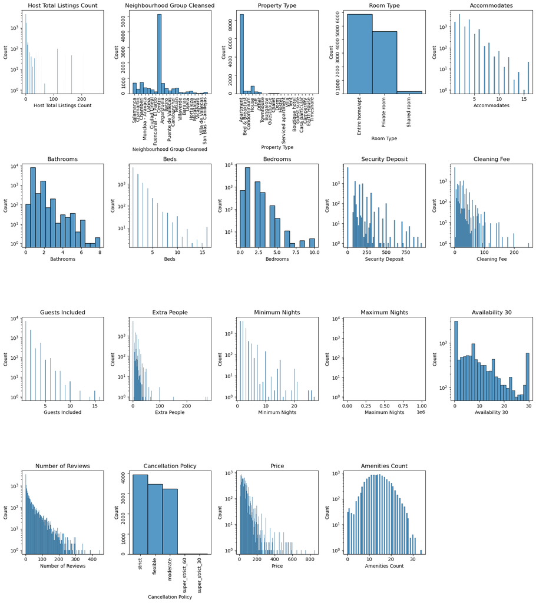

```python
import math

df_plot = df_madrid.drop("Thumbnail Url", axis=1)
num_cols = len(df_plot.columns)
num_rows = math.ceil(num_cols / 5)

# Creo los subplots con los cálculos anteriores.
fig, axes = plt.subplots(nrows=num_rows, ncols=5, figsize=(16, num_rows * 4.5))

# Coloco los axes en fila para poderlos mover mejor.
axes = axes.flatten()

# Eliminamos las celdas que no tengan gráfica
for i in range(num_cols, num_rows * 5):
    fig.delaxes(axes[i])

# Loop para colocar secuencialmente las gráficas en sus subplots
for i, col in enumerate(df_plot.columns):
    # Creao un histograma para cada columna en el subplot correspondiente
    # Si es categórica, que ajuste el parámetro de hisplot() discrete=True

    if col in ["Neighbourhood Group Cleansed", "Property Type", "Room Type", "Cancellation Policy"]:
        # En las categóricas giraré las etiquetas
        sns.histplot(df_plot[col], ax=axes[i], discrete=True)
        axes[i].set_title(col)
        axes[i].tick_params(labelrotation=90)
    else:
        # Usaré una escala logarítmica en el eje y para resaltar los valores más pequeños
        sns.histplot(df_plot[col], ax=axes[i])
        axes[i].set_title(col)
        axes[i].set_yscale("log")

plt.tight_layout()
plt.show()
```

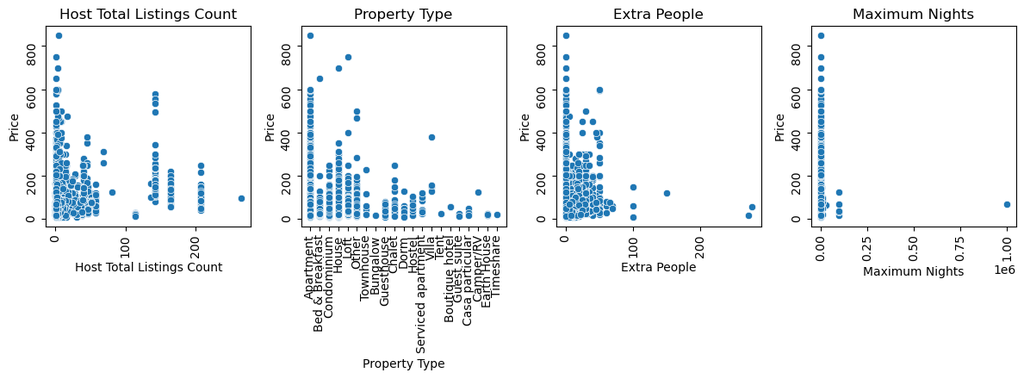

```python
# Autoconfiguración de filas y columnas según el número de columnas del dataframe.
df_plot2 = df_madrid[["Host Total Listings Count", "Property Type", "Extra People", "Maximum Nights"]]
num_cols = len(df_plot2.columns)
num_rows = math.ceil(num_cols / 4) # Para calcular las filas dividimos por 4 columnas de ancho en cada fila, y redondeamos al más alto.

# Creo los subplots con los cálculos anteriores.
fig, axes = plt.subplots(nrows=num_rows, ncols=4, figsize=(12, num_rows * 4.5))

# Coloco los axes en fila para poderlos mover mejor.
axes = axes.flatten()

# Eliminamos las celdas que no tengan gráfica
for i in range(num_cols, num_rows * 4):
    fig.delaxes(axes[i])

# Loop para colocar secuencialmente las gráficas en sus subplots
for i, col in enumerate(df_plot2.columns):
    # Creo un boxplot para cada columna en el subplot correspondiente
    sns.scatterplot(x=df_plot2[col], y=df_madrid["Price"], ax=axes[i])
    axes[i].set_title(col)
    axes[i].tick_params(labelrotation=90)

plt.tight_layout()
plt.show()
```

En casi todas las variables la distribución es right skewed, con valores distribuidos de manera continua, sin saltos grandes. Su continuidad indica que no son outliers.  
Sin embargo, en "Extra people" hay valores muy extremos muy separados de la distribución principal. Especialmente en "Maximum nights", hay valores tan extremos quye hace que el resto de la distribución no se vea. Vamos a tratar estos valores extremos.

#### Outliers:

- Analizamos "Extra People":

```python
df_madrid["Extra People"].describe()
```

```
count    10649.000000
mean         7.163677
std          9.786382
min          0.000000
25%          0.000000
50%          0.000000
75%         13.000000
max        276.000000
Name: Extra People, dtype: float64
```

```python
np.percentile(df_madrid["Extra People"],95)
```

```
24.0
```

```python
# Veamos los 30 valores más altos
df_madrid[df_madrid["Extra People"] > 25].sort_values(by="Extra People")["Extra People"].tail(30)
```

```
5001      50
464       50
8104      50
6561      50
4190      50
8395      50
4251      50
2897      50
2658      50
11263     50
8965      50
11450     50
7327      50
1900      50
1871      50
```

[output cut: 16 more lines]

En este caso se aprecian saltos muy grandes poco consecutivos al final de los datos ordenados. Sin embargo, siguen una cierta continuidad, y podrían ser valores verdaderos relacionados con hoteles u hostales. por los que lo conservaré.

- Ahora veremos "Maximum Nights":

```python
df_madrid["Maximum Nights"].describe()
```

```
count      10649.000000
mean         983.006949
std         9937.468119
min            1.000000
25%          360.000000
50%         1125.000000
75%         1125.000000
max      1000000.000000
Name: Maximum Nights, dtype: float64
```

```python
np.percentile(df_madrid["Maximum Nights"],95)
```

```
1125.0
```

```python
# Veamos los 20 valores más altos
df_madrid[df_madrid["Maximum Nights"] > 25].sort_values(by="Maximum Nights")["Maximum Nights"].tail(24)
```

```
7535        2000
7573        2000
3046        2000
12209       2000
4213        5000
6813        5555
5708        9999
3713        9999
8982        9999
4612       10000
12369      10000
5723       10000
5666       10000
2445       10000
4782       10000
11776      11111
3886       11111
929        30000
7328       99999
8524       99999
5702       99999
4350       99999
7297      100000
1723     1000000
Name: Maximum Nights, dtype: int64
```

Teniendo en cuenta que el 95% de los valores están por debajo de 1125, lo cual indica que no hay un mínimo de noches de alquiler, no parece razonable conservar valores más altos que 5000. Todos los que estén más allé de 5000 se transformarán a 5000. Dado que es un valor de conversión fijo y establecido de antemano, se puede hacer antes del split, ya que no es un valor calculado en base a sumatorias del resto de los valores y no influirá en el entrenamiento.

```python
df_madrid.loc[df_madrid["Maximum Nights"] > 5000, "Maximum Nights"] = 5000
```

```python
df_madrid[df_madrid["Maximum Nights"] > 25].sort_values(by="Maximum Nights")["Maximum Nights"].tail(30)
```

```
8515     1825
8109     1825
2758     1900
8232     1999
11089    2000
2701     2000
7535     2000
7573     2000
3046     2000
12209    2000
4612     5000
8524     5000
6813     5000
12369    5000
5723     5000
```

[output cut: 16 more lines]

Volvamos a revisar el dataframe para continuar codificando las categóticas:

```python
df_madrid.info()
```

```
<class 'pandas.core.frame.DataFrame'>
Index: 10649 entries, 1 to 13999
Data columns (total 20 columns):
 #   Column                        Non-Null Count  Dtype
---  ------                        --------------  -----
 0   Thumbnail Url                 10649 non-null  object
 1   Host Total Listings Count     10649 non-null  float64
 2   Neighbourhood Group Cleansed  10649 non-null  object
 3   Property Type                 10649 non-null  object
 4   Room Type                     10649 non-null  object
 5   Accommodates                  10649 non-null  int64
 6   Bathrooms                     10649 non-null  float64
 7   Beds                          10649 non-null  float64
 8   Bedrooms                      10649 non-null  float64
 9   Security Deposit              10649 non-null  float64
 10  Cleaning Fee                  10649 non-null  float64
 11  Guests Included               10649 non-null  int64
 12  Extra People                  10649 non-null  int64
 13  Minimum Nights                10649 non-null  int64
 14  Maximum Nights                10649 non-null  int64
 15  Availability 30               10649 non-null  int64
 16  Number of Reviews             10649 non-null  int64
 17  Cancellation Policy           10649 non-null  object
 18  Price                         10649 non-null  float64
 19  Amenities Count               10649 non-null  float64
dtypes: float64(8), int64(7), object(5)
memory usage: 2.0+ MB
```

Tenemos varias features que son categóricas. Veamos qué se puede categorizar antes del split:

```python
df_madrid["Neighbourhood Group Cleansed"].unique()
```

```
array(['Salamanca', 'Chamartín', 'Chamberí', 'Moncloa - Aravaca',
       'Latina', 'Ciudad Lineal', 'Fuencarral - El Pardo', 'Centro',
       'Arganzuela', 'Retiro', 'Puente de Vallecas', 'Carabanchel',
       'Tetuán', 'Villaverde', 'Barajas', 'Usera', 'Hortaleza',
       'Moratalaz', 'Vicálvaro', 'Villa de Vallecas',
       'San Blas - Canillejas'], dtype=object)
```

```python
df_madrid["Neighbourhood Group Cleansed"].nunique()
```

```
21
```

```python
df_madrid["Property Type"].unique()
```

```
array(['Apartment', 'Bed & Breakfast', 'Condominium', 'House', 'Loft',
       'Other', 'Townhouse', 'Bungalow', 'Guesthouse', 'Chalet', 'Dorm',
       'Hostel', 'Serviced apartment', 'Villa', 'Tent', 'Boutique hotel',
       'Guest suite', 'Casa particular', 'Camper/RV', 'Earth House',
       'Timeshare'], dtype=object)
```

```python
df_madrid["Property Type"].nunique()
```

```
21
```

```python
df_madrid["Room Type"].unique()
```

```
array(['Entire home/apt', 'Private room', 'Shared room'], dtype=object)
```

```python
df_madrid["Cancellation Policy"].unique()
```

```
array(['strict', 'flexible', 'moderate', 'super_strict_60',
       'super_strict_30'], dtype=object)
```

Todos los valores de las variables están predefinidas por AirBnb y no dependen de mediciones, razón añadida para poderlas codificar antes del split.

- Ahora codificaré "Cancellation Policy" con un LabelEncoding Ordinal, porque esta variable sí que es se hace más restrictiva según sube su categoría, desde un nivel 0 "Flexible" hasta un nivel 4 super estricto 60 días. Además, casualmente los nombres de las categorías ya están ordenados alfabéticamente de menos rígido a más rígido.

```python
# Codificaré con sklearn, ya que tensorflow no permite como entradas strings
from sklearn.preprocessing import LabelEncoder, OneHotEncoder
le_canc = LabelEncoder()
df_madrid["Cancellation Policy"] = le_canc.fit_transform(df_madrid["Cancellation Policy"])
# Veamos las categorías creadas y su correspondencia
listado_canc = [(idx,clase) for idx, clase in enumerate(le_canc.classes_)]
listado_canc
```

```
[(0, 'flexible'),
 (1, 'moderate'),
 (2, 'strict'),
 (3, 'super_strict_30'),
 (4, 'super_strict_60')]
```

```python
df_madrid["Cancellation Policy"].head()
```

```
1    2
2    0
4    0
5    0
6    2
Name: Cancellation Policy, dtype: int64
```

```python
df_madrid.describe()
```

|  | Host Total Listings Count | Accommodates | Bathrooms | Beds | Bedrooms | Security Deposit | Cleaning Fee | Guests Included | Extra People | Minimum Nights | Maximum Nights | Availability 30 | Number of Reviews | Cancellation Policy | Price | Amenities Count |
| --- | --- | --- | --- | --- | --- | --- | --- | --- | --- | --- | --- | --- | --- | --- | --- | --- |
| count | 10649.000000 | 10649.000000 | 10649.000000 | 10649.000000 | 10649.000000 | 10649.000000 | 10649.000000 | 10649.000000 | 10649.000000 | 10649.000000 | 10649.000000 | 10649.000000 | 10649.000000 | 10649.000000 | 10649.000000 | 10649.000000 |
| mean | 8.691145 | 3.075688 | 1.252841 | 1.936238 | 1.275988 | 74.212414 | 16.135506 | 1.553197 | 7.163677 | 2.410367 | 837.193258 | 8.403794 | 25.478636 | 1.045075 | 61.429524 | 13.937741 |
| std | 24.786946 | 1.965972 | 0.603838 | 1.495978 | 0.802178 | 110.366167 | 20.238648 | 1.076616 | 9.786382 | 2.209719 | 508.131887 | 8.694680 | 40.557337 | 0.834342 | 51.927425 | 4.740760 |
| min | 0.000000 | 1.000000 | 0.000000 | 1.000000 | 0.000000 | 0.000000 | 0.000000 | 1.000000 | 0.000000 | 1.000000 | 1.000000 | 0.000000 | 0.000000 | 0.000000 | 9.000000 | 0.000000 |
| 25% | 1.000000 | 2.000000 | 1.000000 | 1.000000 | 1.000000 | 0.000000 | 0.000000 | 1.000000 | 0.000000 | 1.000000 | 360.000000 | 0.000000 | 1.000000 | 0.000000 | 30.000000 | 11.000000 |
| 50% | 2.000000 | 2.000000 | 1.000000 | 1.000000 | 1.000000 | 0.000000 | 10.000000 | 1.000000 | 0.000000 | 2.000000 | 1125.000000 | 6.000000 | 9.000000 | 1.000000 | 50.000000 | 14.000000 |
| 75% | 5.000000 | 4.000000 | 1.000000 | 2.000000 | 1.000000 | 150.000000 | 25.000000 | 2.000000 | 13.000000 | 3.000000 | 1125.000000 | 13.000000 | 32.000000 | 2.000000 | 75.000000 | 17.000000 |
| max | 265.000000 | 16.000000 | 8.000000 | 16.000000 | 10.000000 | 950.000000 | 250.000000 | 16.000000 | 276.000000 | 27.000000 | 5000.000000 | 30.000000 | 446.000000 | 4.000000 | 850.000000 | 34.000000 |

- Ahora, las demás variables usando get_dummies:

```python
df_madrid = pd.get_dummies(df_madrid, columns=["Room Type", "Property Type", "Neighbourhood Group Cleansed"], dtype=int)
df_madrid
```

|  | Thumbnail Url | Host Total Listings Count | Accommodates | Bathrooms | Beds | Bedrooms | Security Deposit | Cleaning Fee | Guests Included | Extra People | ... | Neighbourhood Group Cleansed_Moratalaz | Neighbourhood Group Cleansed_Puente de Vallecas | Neighbourhood Group Cleansed_Retiro | Neighbourhood Group Cleansed_Salamanca | Neighbourhood Group Cleansed_San Blas - Canillejas | Neighbourhood Group Cleansed_Tetuán | Neighbourhood Group Cleansed_Usera | Neighbourhood Group Cleansed_Vicálvaro | Neighbourhood Group Cleansed_Villa de Vallecas | Neighbourhood Group Cleansed_Villaverde |
| --- | --- | --- | --- | --- | --- | --- | --- | --- | --- | --- | --- | --- | --- | --- | --- | --- | --- | --- | --- | --- | --- |
| 1 | https://a0.muscache.com/im/pictures/c4bd0aec-3... | 164.0 | 7 | 2.0 | 5.0 | 2.0 | 100.0 | 60.0 | 1 | 5 | ... | 0 | 0 | 0 | 1 | 0 | 0 | 0 | 0 | 0 | 0 |
| 2 | https://a0.muscache.com/im/pictures/cba43537-1... | 2.0 | 3 | 1.0 | 2.0 | 2.0 | 0.0 | 20.0 | 1 | 0 | ... | 0 | 0 | 0 | 0 | 0 | 0 | 0 | 0 | 0 | 0 |
| 4 | https://a0.muscache.com/im/pictures/43e5e3ce-d... | 1.0 | 1 | 1.0 | 1.0 | 1.0 | 0.0 | 0.0 | 1 | 0 | ... | 0 | 0 | 0 | 0 | 0 | 0 | 0 | 0 | 0 | 0 |
| 5 | https://a0.muscache.com/im/pictures/74093962/e... | 1.0 | 2 | 1.5 | 1.0 | 1.0 | 0.0 | 0.0 | 1 | 0 | ... | 0 | 0 | 0 | 0 | 0 | 0 | 0 | 0 | 0 | 0 |
| 6 | https://a0.muscache.com/im/pictures/27506c35-a... | 1.0 | 6 | 1.0 | 3.0 | 2.0 | 120.0 | 25.0 | 2 | 12 | ... | 0 | 0 | 0 | 0 | 0 | 0 | 0 | 0 | 0 | 0 |
| ... | ... | ... | ... | ... | ... | ... | ... | ... | ... | ... | ... | ... | ... | ... | ... | ... | ... | ... | ... | ... | ... |
| 13995 | https://a0.muscache.com/im/pictures/6f12be9a-7... | 1.0 | 1 | 1.0 | 1.0 | 1.0 | 0.0 | 10.0 | 1 | 22 | ... | 0 | 0 | 0 | 0 | 0 | 0 | 0 | 0 | 0 | 0 |
| 13996 | https://a0.muscache.com/im/pictures/eb603048-c... | 1.0 | 4 | 1.0 | 1.0 | 1.0 | 0.0 | 0.0 | 1 | 0 | ... | 0 | 0 | 0 | 0 | 0 | 0 | 0 | 0 | 0 | 0 |
| 13997 | https://a0.muscache.com/im/pictures/11270498/b... | 2.0 | 6 | 1.0 | 3.0 | 2.0 | 0.0 | 50.0 | 2 | 10 | ... | 0 | 0 | 0 | 0 | 0 | 0 | 0 | 0 | 0 | 0 |
| 13998 | https://a0.muscache.com/im/pictures/0e8bb248-5... | 1.0 | 3 | 1.0 | 1.0 | 1.0 | 150.0 | 24.0 | 2 | 5 | ... | 0 | 0 | 0 | 0 | 0 | 0 | 0 | 0 | 0 | 0 |
| 13999 | https://a0.muscache.com/im/pictures/8135fe55-5... | 1.0 | 1 | 1.0 | 1.0 | 1.0 | 0.0 | 5.0 | 1 | 8 | ... | 0 | 0 | 0 | 0 | 0 | 0 | 0 | 0 | 0 | 0 |

10649 rows × 62 columns

Sólo queda transformar todas las variables al mismo tipo de datos.  
Para ello vamos a inspeccionar primero los rangos de valores existentes antes de hacer el get_dummies (un chunk por encima de este), nos ayudará a reducir los bits del dtype:

```python
df_madrid[df_madrid.columns.difference(["Thumbnail Url"])] = df_madrid[df_madrid.columns.difference(["Thumbnail Url"])].astype("float32")
df_madrid.info()
```

```
<class 'pandas.core.frame.DataFrame'>
Index: 10649 entries, 1 to 13999
Data columns (total 62 columns):
 #   Column                                              Non-Null Count  Dtype
---  ------                                              --------------  -----
 0   Thumbnail Url                                       10649 non-null  object
 1   Host Total Listings Count                           10649 non-null  float32
 2   Accommodates                                        10649 non-null  float32
 3   Bathrooms                                           10649 non-null  float32
 4   Beds                                                10649 non-null  float32
 5   Bedrooms                                            10649 non-null  float32
 6   Security Deposit                                    10649 non-null  float32
 7   Cleaning Fee                                        10649 non-null  float32
 8   Guests Included                                     10649 non-null  float32
 9   Extra People                                        10649 non-null  float32
```

[output cut: 54 more lines]

Ya son del mismo tipo todas las variables, float32.

## ETAPA 2: EXTRACCIÓN DE IMÁGENES

El proceso de extraer las imágenes que podamos conseguir para el modelo convolucional podría producir muchos fallos derivados de la indexación cruzada entre los datasets tabulares y los de imágenes.

- Primero bajaré todas las imágenes que pueda conseguir del dataset que ha quedado tras el filtrado como un solo archivo, guardando los índices del tabular que se han podido recuperar.
- Segundo, filtraremos el dataset tabular según los índices de las filas que han conseguido una imagen.
- Tercero, guardaremos ambos archivos para poder reusar los datos y no tenerlos que descargar de nuevo. El proceso de guardar el tabular como csv y las imágenes en un array de numpy guardará en el minsmo orden los datos, y reseteará los índices usados anteriormente, creándolos de nuevo desde 0 a len(datos), de tal manera que se seguirán correspondiendo correctamente los datos entre los dos archivos.
- Cuarto, cargaremos los nuevos datos sustituyendo las variables que los guardaban anteriormente para optimizar la memoria.
- Quinto, el dataset tabular se dividirá en train, val y test primero. Los datos en cada división tendrán sus propios índices únicos.
- Sexto, crearé los splits de las imágenes usando los índices seleccionados en el split del tabular.

Empezaremos creando la función de descarga de imágenes.

```python
def download_images(paths: list,
                    canvas: tuple = (224, 224),
                    nb_channels: int = 3,
                    max_imgs: Optional[int] = None
                    ) -> tuple:
  """ Download a list of images from url adresses, converting them to a specific
  canvas size.

  Args:
    paths: Paths or url adresses from which to load images.
    canvas: Desired image width and height.
    nb_channels: Channels in images (1 for B/W, 3 for RGB).
    max_imgs: Upper threshold in the number of images to download.

  Return:
    a tuple of:
      - image values
      - indices within the paths that were successfull.

  """
  n_images = len(paths) if not max_imgs else max_imgs
  images = np.zeros((n_images, canvas[0], canvas[1], nb_channels),
                       dtype=np.uint8)
  downloaded_idxs = []

  for i_img, url in enumerate(tqdm(paths, total=n_images)):
    if i_img >= n_images:
      break
    try:
        img = io.imread(url)
        img = cv2.resize(img, (canvas[0], canvas[1]))
        downloaded_idxs.append(i_img)
        images[i_img] = img
    except (IOError, ValueError) as e:  # Unavailable url / conversion error
        pass
  return images[downloaded_idxs], downloaded_idxs
```

Cargamos en dos variables tanto las imágenes como los índices del tabular para los que se han encontrado estas imágenes, para todas las observaciones posibles del dataset, y comprobamos que se pueden leer:

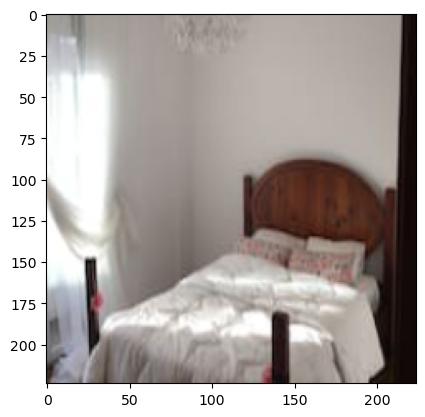

```python
images_raw, idxs = download_images(df_madrid['Thumbnail Url'])
plt.imshow(images_raw[1])
```

Escalamos los valores de los píxeles de las imágenes con una técnica de Max Scaler, sobre el valor máximo que pueden tomar los píxeles. Son de una profundidad de 8 bits de color, por lo tanto 256 valores posibles:

```python
images_raw = images_raw.astype("float32")
print(images_raw.shape)

images_scaled = images_raw.astype("float32") / 255.
images_scaled.shape
```

```
(8299, 224, 224, 3)
```

```
(8299, 224, 224, 3)
```

Ahora nos quedamos del tabular sólo las filas cuyos índices coinciden con los de las imágenes encontradas:

```python
filtered_df = df_madrid.iloc[idxs]
filtered_df
```

|  | Thumbnail Url | Host Total Listings Count | Accommodates | Bathrooms | Beds | Bedrooms | Security Deposit | Cleaning Fee | Guests Included | Extra People | ... | Neighbourhood Group Cleansed_Moratalaz | Neighbourhood Group Cleansed_Puente de Vallecas | Neighbourhood Group Cleansed_Retiro | Neighbourhood Group Cleansed_Salamanca | Neighbourhood Group Cleansed_San Blas - Canillejas | Neighbourhood Group Cleansed_Tetuán | Neighbourhood Group Cleansed_Usera | Neighbourhood Group Cleansed_Vicálvaro | Neighbourhood Group Cleansed_Villa de Vallecas | Neighbourhood Group Cleansed_Villaverde |
| --- | --- | --- | --- | --- | --- | --- | --- | --- | --- | --- | --- | --- | --- | --- | --- | --- | --- | --- | --- | --- | --- |
| 1 | https://a0.muscache.com/im/pictures/c4bd0aec-3... | 164.0 | 7.0 | 2.0 | 5.0 | 2.0 | 100.0 | 60.0 | 1.0 | 5.0 | ... | 0.0 | 0.0 | 0.0 | 1.0 | 0.0 | 0.0 | 0.0 | 0.0 | 0.0 | 0.0 |
| 2 | https://a0.muscache.com/im/pictures/cba43537-1... | 2.0 | 3.0 | 1.0 | 2.0 | 2.0 | 0.0 | 20.0 | 1.0 | 0.0 | ... | 0.0 | 0.0 | 0.0 | 0.0 | 0.0 | 0.0 | 0.0 | 0.0 | 0.0 | 0.0 |
| 4 | https://a0.muscache.com/im/pictures/43e5e3ce-d... | 1.0 | 1.0 | 1.0 | 1.0 | 1.0 | 0.0 | 0.0 | 1.0 | 0.0 | ... | 0.0 | 0.0 | 0.0 | 0.0 | 0.0 | 0.0 | 0.0 | 0.0 | 0.0 | 0.0 |
| 5 | https://a0.muscache.com/im/pictures/74093962/e... | 1.0 | 2.0 | 1.5 | 1.0 | 1.0 | 0.0 | 0.0 | 1.0 | 0.0 | ... | 0.0 | 0.0 | 0.0 | 0.0 | 0.0 | 0.0 | 0.0 | 0.0 | 0.0 | 0.0 |
| 6 | https://a0.muscache.com/im/pictures/27506c35-a... | 1.0 | 6.0 | 1.0 | 3.0 | 2.0 | 120.0 | 25.0 | 2.0 | 12.0 | ... | 0.0 | 0.0 | 0.0 | 0.0 | 0.0 | 0.0 | 0.0 | 0.0 | 0.0 | 0.0 |
| ... | ... | ... | ... | ... | ... | ... | ... | ... | ... | ... | ... | ... | ... | ... | ... | ... | ... | ... | ... | ... | ... |
| 13993 | https://a0.muscache.com/im/pictures/105195120/... | 11.0 | 8.0 | 2.0 | 4.0 | 2.0 | 0.0 | 39.0 | 4.0 | 19.0 | ... | 0.0 | 0.0 | 0.0 | 0.0 | 0.0 | 0.0 | 0.0 | 0.0 | 0.0 | 0.0 |
| 13996 | https://a0.muscache.com/im/pictures/eb603048-c... | 1.0 | 4.0 | 1.0 | 1.0 | 1.0 | 0.0 | 0.0 | 1.0 | 0.0 | ... | 0.0 | 0.0 | 0.0 | 0.0 | 0.0 | 0.0 | 0.0 | 0.0 | 0.0 | 0.0 |
| 13997 | https://a0.muscache.com/im/pictures/11270498/b... | 2.0 | 6.0 | 1.0 | 3.0 | 2.0 | 0.0 | 50.0 | 2.0 | 10.0 | ... | 0.0 | 0.0 | 0.0 | 0.0 | 0.0 | 0.0 | 0.0 | 0.0 | 0.0 | 0.0 |
| 13998 | https://a0.muscache.com/im/pictures/0e8bb248-5... | 1.0 | 3.0 | 1.0 | 1.0 | 1.0 | 150.0 | 24.0 | 2.0 | 5.0 | ... | 0.0 | 0.0 | 0.0 | 0.0 | 0.0 | 0.0 | 0.0 | 0.0 | 0.0 | 0.0 |
| 13999 | https://a0.muscache.com/im/pictures/8135fe55-5... | 1.0 | 1.0 | 1.0 | 1.0 | 1.0 | 0.0 | 5.0 | 1.0 | 8.0 | ... | 0.0 | 0.0 | 0.0 | 0.0 | 0.0 | 0.0 | 0.0 | 0.0 | 0.0 | 0.0 |

8299 rows × 62 columns

Guardamos en el disco un array de numpy que contiene las imágenes, y en un .csv el dataset resultante del filtrado. Este proceso resetea los índices de ambos archivos, que empiezan de nuevo de 0 los dos, quedando sincronizadas las imágenes con su observación nuevamente:

```python
np.save('images_raw.npy', images_raw)
np.save('images_scaled.npy', images_scaled)
filtered_df.to_csv('filtered_data.csv', sep=';', index=False)
```

## ETAPA 3: SPLIT DE DATOS Y FINALIZACIÓN EN ARRAYS

Cargamos los ficheros para comprobar su tamaño y los usamos a partir de ahora para el flujo de trabajo. A partir de aquí esto podría comenzar un notebook diferente, con procesos separados para la ingesta de datos y para el modelado.

```python
from tensorflow.keras.models import Sequential
from tensorflow.keras.layers import Dense, Flatten, Conv2D
from tensorflow.keras.optimizers import Adam, SGD
from tensorflow.keras.layers import MaxPooling2D
from tensorflow.keras.layers import BatchNormalization
from tensorflow.keras.layers import Dropout
from tensorflow.keras.applications import VGG16, VGG19, ResNet50
from tensorflow.keras.applications import imagenet_utils
from tensorflow.keras.applications.inception_v3 import preprocess_input
from tensorflow.keras import callbacks, regularizers
from tensorflow.keras import optimizers, Model
from tensorflow.keras.preprocessing.image import img_to_array
from tensorflow.keras.preprocessing.image import load_img
from sklearn.model_selection import train_test_split
from sklearn.preprocessing import MinMaxScaler, StandardScaler
from sklearn.metrics import mean_squared_error
import math
import pandas as pd
import numpy as np
import tensorflow as tf
import matplotlib.pyplot as plt
import seaborn as sns
import scipy.stats as sp
import cv2
import imageio.v3 as io
from tqdm import tqdm

# Para hacerlo reproducible
np.random.seed(42)
```

```python
# Comprobamos a abrirlos de nuevo
saved_data = pd.read_csv("filtered_data.csv", sep=';')
images_raw = np.load("images_raw.npy")
images_scaled = np.load("images_scaled.npy")
saved_data.shape, images_raw.shape, images_scaled.shape
```

```
((8299, 62), (8299, 224, 224, 3), (8299, 224, 224, 3))
```

En primer lugar, separaremos la variable target de las features:

```python
feats = saved_data.drop("Price", axis=1)
y = saved_data.Price
print(feats.shape)
print(y.shape)
```

```
(8299, 61)
(8299,)
```

En un primer split, separamos los datos de test del resto:

```python
"""X_raw, X_test, y_raw, y_test, images_raw, ims_test = train_test_split(feats, y, images, test_size=0.25, random_state=2017)
print(X_raw.shape, X_test.shape, y_raw.shape, y_test.shape, images_raw.shape, ims_test.shape)"""
X_raw, X_test, y_raw, y_test = train_test_split(feats, y, test_size=0.25, random_state=1973)
print(X_raw.shape, X_test.shape, y_raw.shape, y_test.shape)
```

```
(6224, 61) (2075, 61) (6224,) (2075,)
```

En un segundo split, los datos restantes del anterior los volvemos a dividir, esta vez ya en train y validation:

```python
"""X_train, X_val, y_train, y_val, ims_train, ims_val = train_test_split(X_raw, y_raw, images_raw, test_size=0.15, random_state=2017)
print(X_train.shape, X_val.shape, y_train.shape, y_val.shape, ims_train.shape, ims_val.shape)"""
X_train, X_val, y_train, y_val = train_test_split(X_raw, y_raw, test_size=0.15, random_state=1973)
print(X_train.shape, X_val.shape, y_train.shape, y_val.shape)
```

```
(5290, 61) (934, 61) (5290,) (934,)
```

Ahora dividimos el array de imágenes usando los índices de los splits

```python
# Debido a los problemas que he estado teniendo con las predicciones de imagen, mantendré dos conjuntos de datasets de imágenes,
# uno con los valores originales para darselos a modelos y dejar que la función preprocess_input() decida es escalado,
# y otro escalado sobre 255. para hacer otros modelos.

images_raw_train = images_raw[X_train.index].astype("int")
images_raw_val = images_raw[X_val.index].astype("int")
images_raw_test = images_raw[X_test.index].astype("int")
images_scaled_train = images_scaled[X_train.index]
images_scaled_val = images_scaled[X_val.index]
images_scaled_test = images_scaled[X_test.index]
```

Compruebo que los índices corresponden entre los dataset de imagen y los de tabulares:

Para comprobar que el proceso se ha realizado bien, cotejaré la imagen online de cualquier observación, usando su campo url, con la imagen presente en el array de Numpy.  
Crearé dos funciones encadenadas para pedirle al usuario su elección de comparación.

```python
#  Compararemos ambas imágenes con una función que he preparado:
def check1():
    while True:
        opcion = input("Por favor, introduce el split a testear: 0 para Train, 1 para Validation, 2 para Test: ")
        if opcion in ['0', '1', '2']:
            opcion = int(opcion)
            if opcion == 0:
                return X_train, images_raw_train, images_scaled_train
            elif opcion == 1:
                return X_val, images_raw_val, images_scaled_val
            elif opcion == 2:
                return X_test, images_raw_test, images_scaled_test
        else:
            print("Valor incorrecto, vuelve a intentarlo.")

def comparar():
    split, ims_raw_split, ims_scaled_split = check1()
    while True:
        resp = int(input(f"\nIntroduce un índice integer cualquiera hasta el {split.shape[0]} : "))
        if 0 <= resp <= split.shape[0]:
            print("\n·HAZ CLICK en el siguiente enlace y compara el resultado de la web con las imágenes que aparecen abajo:\n")
            fig, axes = plt.subplots(ncols=2, figsize=(12, 6))
            axes[0].imshow(ims_raw_split[resp])
            axes[1].imshow(ims_scaled_split[resp])
            axes[0].set_title("Imagen en dataset sin escalar")
            axes[1].set_title("Imagen en dataset escalado")
            return split.iloc[resp][0]
        else:
            print("Valor no válido. Por favor, introduce un valor válido.")
```

Ejecutamos la función frontend para la comparación:

```
·HAZ CLICK en el siguiente enlace y compara el resultado de la web con las imágenes que aparecen abajo:
```

```
'https://a0.muscache.com/im/pictures/99542873/999916d5_original.jpg?aki_policy=small'
```

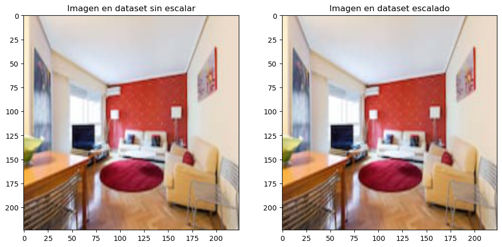

```python
comparar()
```

Tras esto, sólo queda eliminar la variable de las imágenes del dataframe:

```python
X_train = X_train.drop(["Thumbnail Url"], axis=1)
X_test = X_test.drop(["Thumbnail Url"], axis=1)
X_val = X_val.drop(["Thumbnail Url"], axis=1)
```

```python
X_train.iloc[0]
```

```
Host Total Listings Count                               1.0
Accommodates                                            4.0
Bathrooms                                               1.0
Beds                                                    3.0
Bedrooms                                                2.0
Security Deposit                                      100.0
Cleaning Fee                                           40.0
Guests Included                                         2.0
Extra People                                           10.0
Minimum Nights                                          1.0
Maximum Nights                                         99.0
Availability 30                                         6.0
Number of Reviews                                     136.0
Cancellation Policy                                     2.0
Amenities Count                                        19.0
Room Type_Entire home/apt                               1.0
Room Type_Private room                                  0.0
Room Type_Shared room                                   0.0
Property Type_Apartment                                 1.0
Property Type_Bed & Breakfast                           0.0
Property Type_Boutique hotel                            0.0
Property Type_Bungalow                                  0.0
Property Type_Camper/RV                                 0.0
Property Type_Casa particular                           0.0
Property Type_Chalet                                    0.0
Property Type_Condominium                               0.0
Property Type_Dorm                                      0.0
Property Type_Earth House                               0.0
Property Type_Guest suite                               0.0
Property Type_Guesthouse                                0.0
Property Type_Hostel                                    0.0
Property Type_House                                     0.0
Property Type_Loft                                      0.0
Property Type_Other                                     0.0
Property Type_Serviced apartment                        0.0
Property Type_Tent                                      0.0
Property Type_Timeshare                                 0.0
Property Type_Townhouse                                 0.0
Property Type_Villa                                     0.0
Neighbourhood Group Cleansed_Arganzuela                 0.0
Neighbourhood Group Cleansed_Barajas                    0.0
Neighbourhood Group Cleansed_Carabanchel                0.0
Neighbourhood Group Cleansed_Centro                     1.0
Neighbourhood Group Cleansed_Chamartín                  0.0
Neighbourhood Group Cleansed_Chamberí                   0.0
Neighbourhood Group Cleansed_Ciudad Lineal              0.0
Neighbourhood Group Cleansed_Fuencarral - El Pardo      0.0
Neighbourhood Group Cleansed_Hortaleza                  0.0
Neighbourhood Group Cleansed_Latina                     0.0
Neighbourhood Group Cleansed_Moncloa - Aravaca          0.0
Neighbourhood Group Cleansed_Moratalaz                  0.0
Neighbourhood Group Cleansed_Puente de Vallecas         0.0
Neighbourhood Group Cleansed_Retiro                     0.0
Neighbourhood Group Cleansed_Salamanca                  0.0
Neighbourhood Group Cleansed_San Blas - Canillejas      0.0
Neighbourhood Group Cleansed_Tetuán                     0.0
Neighbourhood Group Cleansed_Usera                      0.0
Neighbourhood Group Cleansed_Vicálvaro                  0.0
Neighbourhood Group Cleansed_Villa de Vallecas          0.0
Neighbourhood Group Cleansed_Villaverde                 0.0
Name: 6605, dtype: float64
```

Vamos a escalar los valores no one hot de las features, ya que los one hot ya están escalados a 0 ó 1, y también escalaremos el target:

```python
X_train_scaled = X_train.copy()
X_test_scaled = X_test.copy()
X_val_scaled = X_val.copy()

scalerX = MinMaxScaler(feature_range=(0, 1)).fit(X_train_scaled.iloc[:,0:15])

X_train_scaled.iloc[:,0:15] = scalerX.transform(X_train_scaled.iloc[:,0:15])
X_test_scaled.iloc[:,0:15] = scalerX.transform(X_test_scaled.iloc[:,0:15])
X_val_scaled.iloc[:,0:15] = scalerX.transform(X_val_scaled.iloc[:,0:15])

X_train_scaled = np.array(X_train_scaled)
X_test_scaled = np.array(X_test_scaled)
X_val_scaled = np.array(X_val_scaled)

y_train_scaled = np.array(y_train).reshape(-1,1)
y_test_scaled = np.array(y_test).reshape(-1,1)
y_val_scaled = np.array(y_val).reshape(-1,1)

scalerY = MinMaxScaler().fit(y_train_scaled)

y_train_scaled = scalerY.transform(y_train_scaled)
y_test_scaled = scalerY.transform(y_test_scaled)
y_val_scaled = scalerY.transform(y_val_scaled)
```

Ahora compruebo que se invierte correctamente:

```python
scalerX.inverse_transform(X_train_scaled[:,0:15])
```

```
array([[  1.,   4.,   1., ..., 136.,   2.,  19.],
       [  1.,   4.,   2., ...,   6.,   0.,  19.],
       [  2.,   4.,   2., ...,  34.,   1.,  22.],
       ...,
       [  1.,   4.,   1., ...,  71.,   1.,  16.],
       [  1.,   2.,   2., ...,  23.,   0.,  20.],
       [207.,   2.,   1., ...,   2.,   2.,   6.]])
```

```python
X_train.iloc[:,0:15]
```

|  | Host Total Listings Count | Accommodates | Bathrooms | Beds | Bedrooms | Security Deposit | Cleaning Fee | Guests Included | Extra People | Minimum Nights | Maximum Nights | Availability 30 | Number of Reviews | Cancellation Policy | Amenities Count |
| --- | --- | --- | --- | --- | --- | --- | --- | --- | --- | --- | --- | --- | --- | --- | --- |
| 6605 | 1.0 | 4.0 | 1.0 | 3.0 | 2.0 | 100.0 | 40.0 | 2.0 | 10.0 | 1.0 | 99.0 | 6.0 | 136.0 | 2.0 | 19.0 |
| 3046 | 1.0 | 4.0 | 2.0 | 3.0 | 2.0 | 200.0 | 36.0 | 4.0 | 15.0 | 2.0 | 1125.0 | 12.0 | 6.0 | 0.0 | 19.0 |
| 4704 | 2.0 | 4.0 | 2.0 | 2.0 | 2.0 | 200.0 | 25.0 | 4.0 | 0.0 | 5.0 | 1125.0 | 0.0 | 34.0 | 1.0 | 22.0 |
| 2639 | 1.0 | 2.0 | 1.0 | 1.0 | 1.0 | 0.0 | 0.0 | 1.0 | 10.0 | 2.0 | 30.0 | 29.0 | 0.0 | 2.0 | 10.0 |
| 3243 | 8.0 | 2.0 | 1.0 | 1.0 | 1.0 | 0.0 | 0.0 | 1.0 | 0.0 | 2.0 | 28.0 | 0.0 | 28.0 | 2.0 | 12.0 |
| ... | ... | ... | ... | ... | ... | ... | ... | ... | ... | ... | ... | ... | ... | ... | ... |
| 395 | 1.0 | 6.0 | 1.0 | 4.0 | 2.0 | 100.0 | 25.0 | 1.0 | 0.0 | 2.0 | 1125.0 | 9.0 | 11.0 | 1.0 | 14.0 |
| 4611 | 1.0 | 2.0 | 2.0 | 1.0 | 1.0 | 0.0 | 0.0 | 1.0 | 0.0 | 1.0 | 1125.0 | 0.0 | 0.0 | 2.0 | 9.0 |
| 2578 | 1.0 | 4.0 | 1.0 | 2.0 | 2.0 | 0.0 | 0.0 | 1.0 | 0.0 | 3.0 | 1125.0 | 11.0 | 71.0 | 1.0 | 16.0 |
| 3478 | 1.0 | 2.0 | 2.0 | 1.0 | 1.0 | 150.0 | 20.0 | 1.0 | 0.0 | 2.0 | 1125.0 | 11.0 | 23.0 | 0.0 | 20.0 |
| 2926 | 207.0 | 2.0 | 1.0 | 1.0 | 1.0 | 200.0 | 0.0 | 1.0 | 0.0 | 2.0 | 1125.0 | 3.0 | 2.0 | 2.0 | 6.0 |

5290 rows × 15 columns

## ETAPA 4: MODELADO DE LA RED PARA LAS IMÁGENES

## Modelo manual

Como proceso de comparación, empezaré con un modelo creado manualmente capa a capa para la red CNN de las imágenes. Usaré el modelo secuencial de 3 capas con la siguiente configuración tras una larga iteración de pruebas con cambios en los parámetros:  
· Activación ReLU en capas intermedias y Linear para la capa de predicciones.  
· Optimización de overfitting con Dropout y MaxPooling.  
· El optimizador de gradiente es Adam.  
· La métrica escogida es MSE al ser una regresión y no clasificación.

```python
# Definimos el modelo
model = Sequential()

# Capas convolucionales y de optimización
model.add(Conv2D(224, (3, 3), activation='relu', input_shape=(224, 224, 3)))
model.add(MaxPooling2D((2, 2)))
model.add(Dropout(0.35))
model.add(Conv2D(128, (3, 3), activation='relu'))
model.add(MaxPooling2D((2, 2)))
model.add(Dropout(0.35))
model.add(Conv2D(64, (3, 3), activation='relu'))
model.add(MaxPooling2D((2, 2)))
model.add(Dropout(0.35))

# Capa de salida para la Densa
model.add(Flatten())

# Capas Densas
model.add(Dense(512, activation='relu'))
Dropout(0.35)
model.add(Dense(1, activation='linear'))


# Compilamos el modelo
model.compile(optimizer=Adam(learning_rate=5e-4), loss='mean_squared_error', metrics=["mean_squared_error"])

# Resumen del modelo
model.summary()
```

[output not shown]

```
Model: "sequential"
_________________________________________________________________
 Layer (type)                Output Shape              Param #
=================================================================
 conv2d (Conv2D)             (None, 222, 222, 224)     6272

 max_pooling2d (MaxPooling2  (None, 111, 111, 224)     0
 D)

 dropout (Dropout)           (None, 111, 111, 224)     0

 conv2d_1 (Conv2D)           (None, 109, 109, 128)     258176

 max_pooling2d_1 (MaxPoolin  (None, 54, 54, 128)       0
 g2D)

 dropout_1 (Dropout)         (None, 54, 54, 128)       0

 conv2d_2 (Conv2D)           (None, 52, 52, 64)        73792

 max_pooling2d_2 (MaxPoolin  (None, 26, 26, 64)        0
 g2D)

 dropout_2 (Dropout)         (None, 26, 26, 64)        0

 flatten (Flatten)           (None, 43264)             0

 dense (Dense)               (None, 512)               22151680

 dense_1 (Dense)             (None, 1)                 513

=================================================================
Total params: 22490433 (85.79 MB)
Trainable params: 22490433 (85.79 MB)
Non-trainable params: 0 (0.00 Byte)
_________________________________________________________________
```

```python
# Entrenamos el modelo y guardamos el histórico
H = model.fit(images_scaled_train, y_train_scaled, epochs=20, batch_size=32, validation_data=(images_scaled_val, y_val_scaled))
```

```
2024-03-10 15:14:28.667745: I tensorflow/core/grappler/optimizers/custom_graph_optimizer_registry.cc:117] Plugin optimizer for device_type GPU is enabled.
2024-03-10 15:14:28.693112: E tensorflow/core/grappler/optimizers/meta_optimizer.cc:961] model_pruner failed: INVALID_ARGUMENT: Graph does not contain terminal node Adam/AssignAddVariableOp.
```

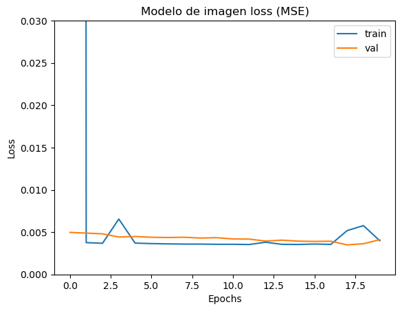

```python
# Dibujamos la curva del histórico de pérdidas:
plt.plot(H.history['loss'], label='train')
plt.plot(H.history['val_loss'], label='val')
plt.title('Modelo de imagen loss (MSE)')
plt.xlabel('Epochs')
plt.ylim(0,0.03)
plt.ylabel('Loss')
plt.legend()
plt.show()
```

```python
# Hacemos la predicción:
predictions_image_manual = model.predict(images_scaled_test)
```

```python
# Compruebo la salida de las predicciones y las guardo para comparar:
np.save('predictions_image_manual.npy', predictions_image_manual)
predictions_image_manual
```

```
array([[0.01793893],
       [0.0403351 ],
       [0.02459423],
       ...,
       [0.03740032],
       [0.02389954],
       [0.0358905 ]], dtype=float32)
```

```python
# Ahora voy a evaluar el rendimiento del modelo con los 3 splits de datos
train_mse_man = model.evaluate(images_scaled_train, y_train_scaled)
val_mse_man = model.evaluate(images_scaled_val, y_val_scaled)
test_mse_man = model.evaluate(images_scaled_test, y_test_scaled)

print("Train Score:", train_mse_man)
print("Validation Score:", val_mse_man)
print("Test Score:", test_mse_man)
```

```
Train Score: [0.004125052131712437, 0.004125052131712437]
Validation Score: [0.004110243637114763, 0.004110243637114763]
Test Score: [0.005323693621903658, 0.005323693621903658]
```

```python
# Para poder ver el error en unidades reales, tenemos que la inversa del cuadrado del error, y luego desescalar los resultados para conseguir el error en euros:

# Error no cuadrado
train_rmse_man = math.sqrt(train_mse_man[0])
print('Train Score: %.3f RMSE' % (train_rmse_man))
val_rmse_man = math.sqrt(val_mse_man[0])
print('Train Score: %.3f RMSE' % (val_rmse_man))
test_rmse_man = math.sqrt(test_mse_man[0])
print('Test Score: %.3f RMSE' % (test_rmse_man))

# Ahora lo desescalamos:
train_error_euro = scalerY.inverse_transform(np.reshape(train_rmse_man,(-1,1)))
val_error_euro = scalerY.inverse_transform(np.reshape(val_rmse_man,(-1,1)))
test_error_euro = scalerY.inverse_transform(np.reshape(test_rmse_man,(-1,1)))

print('Train error in Euros: %.2f Euros' % (train_error_euro))
print('Train error in Euros: %.2f Euros' % (val_error_euro))
print('Test error in Euros: %.2f Euros' % (test_error_euro))
```

```
Train Score: 0.064 RMSE
Train Score: 0.064 RMSE
Test Score: 0.073 RMSE
Train error in Euros: 63.95 Euros
Train error in Euros: 63.85 Euros
Test error in Euros: 71.29 Euros
```

```python
# Guardamos el modelo para poderlo usar sin ejecutar todo lo anterior
model.save("modelo_manual")
```

```
INFO:tensorflow:Assets written to: modelo_manual/assets
```

```
INFO:tensorflow:Assets written to: modelo_manual/assets
```

## Modelo preentrenado

Ahora compararemos el resultado de un m,odelo preentrenado. Primero creamos el modelo base preentrenado con una red VGG19 y bajamos la red de pesos entrenados correspondiente al modelo.  
Usaremos las mismas optimizaciones y activadores que en el anterior.

```python
base_model = VGG19(weights="imagenet", include_top=False, input_shape=(224,224,3))
base_model.summary()
```

[output not shown]

```
Model: "vgg19"
_________________________________________________________________
 Layer (type)                Output Shape              Param #
=================================================================
 input_1 (InputLayer)        [(None, 224, 224, 3)]     0

 block1_conv1 (Conv2D)       (None, 224, 224, 64)      1792

 block1_conv2 (Conv2D)       (None, 224, 224, 64)      36928

 block1_pool (MaxPooling2D)  (None, 112, 112, 64)      0

 block2_conv1 (Conv2D)       (None, 112, 112, 128)     73856

 block2_conv2 (Conv2D)       (None, 112, 112, 128)     147584

 block2_pool (MaxPooling2D)  (None, 56, 56, 128)       0

 block3_conv1 (Conv2D)       (None, 56, 56, 256)       295168

 block3_conv2 (Conv2D)       (None, 56, 56, 256)       590080

 block3_conv3 (Conv2D)       (None, 56, 56, 256)       590080

 block3_conv4 (Conv2D)       (None, 56, 56, 256)       590080

 block3_pool (MaxPooling2D)  (None, 28, 28, 256)       0

 block4_conv1 (Conv2D)       (None, 28, 28, 512)       1180160

 block4_conv2 (Conv2D)       (None, 28, 28, 512)       2359808

 block4_conv3 (Conv2D)       (None, 28, 28, 512)       2359808

 block4_conv4 (Conv2D)       (None, 28, 28, 512)       2359808

 block4_pool (MaxPooling2D)  (None, 14, 14, 512)       0

 block5_conv1 (Conv2D)       (None, 14, 14, 512)       2359808

 block5_conv2 (Conv2D)       (None, 14, 14, 512)       2359808

 block5_conv3 (Conv2D)       (None, 14, 14, 512)       2359808

 block5_conv4 (Conv2D)       (None, 14, 14, 512)       2359808

 block5_pool (MaxPooling2D)  (None, 7, 7, 512)         0

=================================================================
Total params: 20024384 (76.39 MB)
Trainable params: 20024384 (76.39 MB)
Non-trainable params: 0 (0.00 Byte)
_________________________________________________________________
```

Congelamos las capas y le añadimos nuestro regresor:

```python
# Congelamos todas las capas de nuestro base_model para que no se entrenen
for layer in base_model.layers:
    layer.trainable = False
    print('Capa ' + layer.name + ' congelada.')


# Cogemos la última capa del model y le añadimos nuestro regresor (top_model)
last = base_model.layers[-1].output
x = Flatten()(last)
x = Dense(images_scaled_train.shape[0], activation='relu', name='fc1')(x)
x = Dropout(0.10)(x)
x = Dense(1, activation='linear', name='predictions')(x)
model_pre = Model(base_model.input, x)


# Compilamos el modelo
model_pre.compile(optimizer=Adam(learning_rate=1e-4), loss='mean_squared_error', metrics=['mean_squared_error'])

# vemos la estructura del modelo
model_pre.summary()
```

```
WARNING:absl:At this time, the v2.11+ optimizer `tf.keras.optimizers.Adam` runs slowly on M1/M2 Macs, please use the legacy Keras optimizer instead, located at `tf.keras.optimizers.legacy.Adam`.
```

```
Capa input_1 congelada.
Capa block1_conv1 congelada.
Capa block1_conv2 congelada.
Capa block1_pool congelada.
Capa block2_conv1 congelada.
Capa block2_conv2 congelada.
Capa block2_pool congelada.
Capa block3_conv1 congelada.
Capa block3_conv2 congelada.
Capa block3_conv3 congelada.
Capa block3_conv4 congelada.
Capa block3_pool congelada.
Capa block4_conv1 congelada.
Capa block4_conv2 congelada.
Capa block4_conv3 congelada.
Capa block4_conv4 congelada.
Capa block4_pool congelada.
Capa block5_conv1 congelada.
Capa block5_conv2 congelada.
Capa block5_conv3 congelada.
Capa block5_conv4 congelada.
Capa block5_pool congelada.
Model: "model"
_________________________________________________________________
 Layer (type)                Output Shape              Param #
=================================================================
 input_1 (InputLayer)        [(None, 224, 224, 3)]     0

 block1_conv1 (Conv2D)       (None, 224, 224, 64)      1792

 block1_conv2 (Conv2D)       (None, 224, 224, 64)      36928

 block1_pool (MaxPooling2D)  (None, 112, 112, 64)      0

 block2_conv1 (Conv2D)       (None, 112, 112, 128)     73856

 block2_conv2 (Conv2D)       (None, 112, 112, 128)     147584

 block2_pool (MaxPooling2D)  (None, 56, 56, 128)       0

```

[output cut: 28 more lines]

```
 block5_pool (MaxPooling2D)  (None, 7, 7, 512)         0

 flatten (Flatten)           (None, 25088)             0

 fc1 (Dense)                 (None, 5290)              132720810

 dropout (Dropout)           (None, 5290)              0

 predictions (Dense)         (None, 1)                 5291

=================================================================
Total params: 152750485 (582.70 MB)
Trainable params: 132726101 (506.31 MB)
Non-trainable params: 20024384 (76.39 MB)
_________________________________________________________________
```

Entrenamos:

```python
H_pre = model_pre.fit(images_scaled_train, y_train_scaled, epochs=20, batch_size=32, shuffle=True, validation_data=(images_scaled_val, y_val_scaled))
```

```
2024-03-10 15:29:04.784369: I tensorflow/core/grappler/optimizers/custom_graph_optimizer_registry.cc:117] Plugin optimizer for device_type GPU is enabled.
2024-03-10 15:29:04.803874: E tensorflow/core/grappler/optimizers/meta_optimizer.cc:961] model_pruner failed: INVALID_ARGUMENT: Graph does not contain terminal node Adam/AssignAddVariableOp.
```

Dibujamos la pérdida en MSE

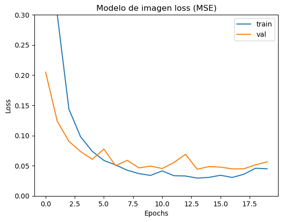

```python
plt.plot(H_pre.history['loss'], label='train')
plt.plot(H_pre.history['val_loss'], label='val')
plt.title('Modelo de imagen loss (MSE)')
plt.xlabel('Epochs')
plt.ylim(0,0.3)
plt.ylabel('Loss')
plt.legend()
plt.show()
```

Hacemos las predicciones sobre test:

```python
predictions_image_vgg19 = model_pre.predict(images_scaled_test)
```

Guardamos las predicciones:

```python
np.save('predictions_image_vgg19.npy', predictions_image_vgg19)
predictions_image_vgg19
```

```
array([[0.1605742 ],
       [0.54981065],
       [0.4117949 ],
       ...,
       [0.09596221],
       [0.00862888],
       [0.42102122]], dtype=float32)
```

Evaluamos con la métrica del modelo (MSE):

```python
train_mse_vgg19 = model_pre.evaluate(images_scaled_train, y_train_scaled)
val_mse_vgg19 = model_pre.evaluate(images_scaled_val, y_val_scaled)
test_mse_vgg19 = model_pre.evaluate(images_scaled_test, y_test_scaled)

print("Train Score:", train_mse_vgg19)
print("Validation Score:", val_mse_vgg19)
print("Test Score:", test_mse_vgg19)
```

```
Train Score: [0.02629821188747883, 0.02629821188747883]
Validation Score: [0.056409455835819244, 0.056409455835819244]
Test Score: [0.053511571139097214, 0.053511571139097214]
```

Ahora vamos a averiguar el error en las unidades reales del target (Euros):

```python
# Error no cuadrado
train_rmse_vgg19 = math.sqrt(train_mse_vgg19[0])
print('Train Score: %.2f RMSE' % (train_rmse_vgg19))
val_rmse_vgg19 = math.sqrt(val_mse_vgg19[0])
print('Train Score: %.2f RMSE' % (val_rmse_vgg19))
test_rmse_vgg19 = math.sqrt(test_mse_vgg19[0])
print('Test Score: %.2f RMSE' % (test_rmse_vgg19))

# Ahora lo desescalamos desescalarmos el error no cuadrado para obtener el error en euros:
train_error_vgg19_euro = scalerY.inverse_transform(np.reshape(train_rmse_vgg19,(-1,1)))
val_error_vgg19_euro = scalerY.inverse_transform(np.reshape(val_rmse_vgg19,(-1,1)))
test_error_vgg19_euro = scalerY.inverse_transform(np.reshape(test_rmse_vgg19,(-1,1)))

print('Train error in Euros: %.2f Euros' % (train_error_vgg19_euro))
print('Train error in Euros: %.2f Euros' % (val_error_vgg19_euro))
print('Test error in Euros: %.2f Euros' % (test_error_vgg19_euro))
```

```
Train Score: 0.16 RMSE
Train Score: 0.24 RMSE
Test Score: 0.23 RMSE
Train error in Euros: 146.22 Euros
Train error in Euros: 209.51 Euros
Test error in Euros: 204.31 Euros
```

```python
model_pre.save("model_pre")
```

```
INFO:tensorflow:Assets written to: model_pre/assets
```

```
INFO:tensorflow:Assets written to: model_pre/assets
```

Este modelo, sólo con Transfer Learning, da unos errores mucho más altos que el modelo manual, ya de por sí excesivos. Sin duda, además de la mala calidad y coherencia global de las imágenes en el dataset, está debido a que las imágenes con las que fué entrenada la red VGG19 no tienen muchos puntos en común con nuestro dataset.

### Ahora vamos a hacer fine-tunning en la última capa convolucional:

```python
# Bloqueamos todas menos la última capa convolucional
for layer in base_model.layers:
    layer.trainable = False
    if layer.name == "block5_conv4":
        layer.trainable = True
        print('Capa ' + layer.name + ' habilitada.')
    else:
        print('Capa ' + layer.name + ' congelada.')

# cogemos la última capa del model y le añadimos nuestro clasificador (top_model)
last = base_model.layers[-1].output
x = Flatten()(last)
x = Dense(images_scaled_train.shape[0], activation='relu', name='fc1')(x)
x = Dropout(0.35)(x)
x = Dense(1, activation='linear', name='predictions')(x)
model_tun = Model(base_model.input, x)

# compilamos el modelo
model_tun.compile(optimizer=Adam(learning_rate=3e-5), loss='mean_squared_error', metrics=['mean_squared_error'])

# vemos la estructura del modelo
model_tun.summary()
```

```
WARNING:absl:At this time, the v2.11+ optimizer `tf.keras.optimizers.Adam` runs slowly on M1/M2 Macs, please use the legacy Keras optimizer instead, located at `tf.keras.optimizers.legacy.Adam`.
```

```
Capa input_1 congelada.
Capa block1_conv1 congelada.
Capa block1_conv2 congelada.
Capa block1_pool congelada.
Capa block2_conv1 congelada.
Capa block2_conv2 congelada.
Capa block2_pool congelada.
Capa block3_conv1 congelada.
Capa block3_conv2 congelada.
Capa block3_conv3 congelada.
Capa block3_conv4 congelada.
Capa block3_pool congelada.
Capa block4_conv1 congelada.
Capa block4_conv2 congelada.
Capa block4_conv3 congelada.
Capa block4_conv4 congelada.
Capa block4_pool congelada.
Capa block5_conv1 congelada.
Capa block5_conv2 congelada.
Capa block5_conv3 congelada.
Capa block5_conv4 habilitada.
Capa block5_pool congelada.
Model: "model_4"
_________________________________________________________________
 Layer (type)                Output Shape              Param #
=================================================================
 input_1 (InputLayer)        [(None, 224, 224, 3)]     0

 block1_conv1 (Conv2D)       (None, 224, 224, 64)      1792

 block1_conv2 (Conv2D)       (None, 224, 224, 64)      36928

 block1_pool (MaxPooling2D)  (None, 112, 112, 64)      0

 block2_conv1 (Conv2D)       (None, 112, 112, 128)     73856

 block2_conv2 (Conv2D)       (None, 112, 112, 128)     147584

 block2_pool (MaxPooling2D)  (None, 56, 56, 128)       0

```

[output cut: 28 more lines]

```
 block5_pool (MaxPooling2D)  (None, 7, 7, 512)         0

 flatten_4 (Flatten)         (None, 25088)             0

 fc1 (Dense)                 (None, 5290)              132720810

 dropout_4 (Dropout)         (None, 5290)              0

 predictions (Dense)         (None, 1)                 5291

=================================================================
Total params: 152750485 (582.70 MB)
Trainable params: 135085909 (515.31 MB)
Non-trainable params: 17664576 (67.39 MB)
_________________________________________________________________
```

Entrenamos:

```python
H_tun = model_tun.fit(images_scaled_train, y_train_scaled, epochs=18, batch_size=64, validation_data=(images_scaled_val, y_val_scaled))
```

```
2024-03-10 16:58:44.666609: E tensorflow/core/grappler/optimizers/meta_optimizer.cc:961] model_pruner failed: INVALID_ARGUMENT: Graph does not contain terminal node Adam/AssignAddVariableOp.
```

De nuevo, predecimos y calculamos el error sobre las unidades reales del target:

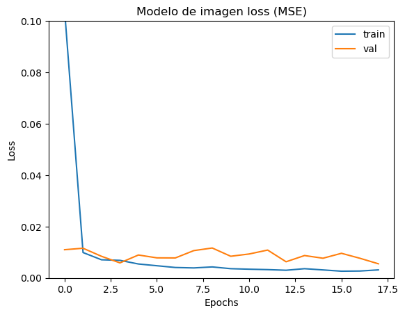

```python
plt.plot(H_tun.history['loss'], label='train')
plt.plot(H_tun.history['val_loss'], label='val')
plt.title('Modelo de imagen loss (MSE)')
plt.xlabel('Epochs')
plt.ylim(0,0.1)
plt.ylabel('Loss')
plt.legend()
plt.show()
```

```python
predictions_image_vgg19_tun = model_tun.predict(images_scaled_test)
```

```python
np.save('predictions_image_vgg19_tun.npy', predictions_image_vgg19_tun)
predictions_image_vgg19_tun
```

```
array([[0.05160545],
       [0.11275161],
       [0.03696929],
       ...,
       [0.10414316],
       [0.14072202],
       [0.11453982]], dtype=float32)
```

```python
train_mse_vgg19_tun = model_tun.evaluate(images_scaled_train, y_train_scaled)
val_mse_vgg19_tun = model_tun.evaluate(images_scaled_val, y_val_scaled)
test_mse_vgg19_tun = model_tun.evaluate(images_scaled_test, y_test_scaled)

print("Train Score:", train_mse_vgg19_tun)
print("Validation Score:", val_mse_vgg19_tun)
print("Test Score:", test_mse_vgg19_tun)
```

```
Train Score: [0.002075325231999159, 0.002075325231999159]
Validation Score: [0.005512109957635403, 0.005512109957635403]
Test Score: [0.0068953987210989, 0.0068953987210989]
```

```python
train_rmse_vgg19_tun = math.sqrt(train_mse_vgg19_tun[0])
print('Train Score: %.2f RMSE' % (train_rmse_vgg19_tun))
val_rmse_vgg19_tun = math.sqrt(val_mse_vgg19_tun[0])
print('Train Score: %.2f RMSE' % (val_rmse_vgg19_tun))
test_rmse_vgg19_tun = math.sqrt(test_mse_vgg19_tun[0])
print('Test Score: %.2f RMSE' % (test_rmse_vgg19_tun))

# Ahora lo desescalamos desescalarmos el error no cuadrado para obtener el error en euros:
train_error_vgg19_tun_euro = scalerY.inverse_transform(np.reshape(train_rmse_vgg19_tun,(-1,1)))
val_error_vgg19_tun_euro = scalerY.inverse_transform(np.reshape(val_rmse_vgg19_tun,(-1,1)))
test_error_vgg19_tun_euro = scalerY.inverse_transform(np.reshape(test_rmse_vgg19_tun,(-1,1)))

print('Train error in Euros: %.2f Euros' % (train_error_vgg19_tun_euro))
print('Train error in Euros: %.2f Euros' % (val_error_vgg19_tun_euro))
print('Test error in Euros: %.2f Euros' % (test_error_vgg19_tun_euro))
```

```
Train Score: 0.05 RMSE
Train Score: 0.07 RMSE
Test Score: 0.08 RMSE
Train error in Euros: 48.27 Euros
Train error in Euros: 72.36 Euros
Test error in Euros: 79.75 Euros
```

```python
model_tun.save("model_tun_last")
```

```
INFO:tensorflow:Assets written to: model_tun_last/assets
```

```
INFO:tensorflow:Assets written to: model_tun_last/assets
```

El resultado del fine-tuning da mucho mejores resultados que el Transfer-Learning, ya que hemos reentreneado la última capa convolucional del VGG19. Esta última capa trae mucho aprendizaje todavía de los patrones en el dataset de entrenamiento de su red, por lo que es posible que si intentamos reentrenar una capa anterior convolucional los resultados finales mejoren. Vamos a usar el bloque anterior de CNNs para reentrenarla.

```python
base_model.summary()
```

```
Model: "vgg19"
_________________________________________________________________
 Layer (type)                Output Shape              Param #
=================================================================
 input_1 (InputLayer)        [(None, 224, 224, 3)]     0

 block1_conv1 (Conv2D)       (None, 224, 224, 64)      1792

 block1_conv2 (Conv2D)       (None, 224, 224, 64)      36928

 block1_pool (MaxPooling2D)  (None, 112, 112, 64)      0

 block2_conv1 (Conv2D)       (None, 112, 112, 128)     73856

 block2_conv2 (Conv2D)       (None, 112, 112, 128)     147584

 block2_pool (MaxPooling2D)  (None, 56, 56, 128)       0

 block3_conv1 (Conv2D)       (None, 56, 56, 256)       295168

 block3_conv2 (Conv2D)       (None, 56, 56, 256)       590080

 block3_conv3 (Conv2D)       (None, 56, 56, 256)       590080

 block3_conv4 (Conv2D)       (None, 56, 56, 256)       590080

 block3_pool (MaxPooling2D)  (None, 28, 28, 256)       0

 block4_conv1 (Conv2D)       (None, 28, 28, 512)       1180160

 block4_conv2 (Conv2D)       (None, 28, 28, 512)       2359808

 block4_conv3 (Conv2D)       (None, 28, 28, 512)       2359808

 block4_conv4 (Conv2D)       (None, 28, 28, 512)       2359808

 block4_pool (MaxPooling2D)  (None, 14, 14, 512)       0

 block5_conv1 (Conv2D)       (None, 14, 14, 512)       2359808

 block5_conv2 (Conv2D)       (None, 14, 14, 512)       2359808

 block5_conv3 (Conv2D)       (None, 14, 14, 512)       2359808

 block5_conv4 (Conv2D)       (None, 14, 14, 512)       2359808

 block5_pool (MaxPooling2D)  (None, 7, 7, 512)         0

=================================================================
Total params: 20024384 (76.39 MB)
Trainable params: 2359808 (9.00 MB)
Non-trainable params: 17664576 (67.39 MB)
_________________________________________________________________
```

```python
# Bloqueamos todas menos la última capa convolucional
for layer in base_model.layers:
    layer.trainable = False
    if layer.name == "block4_conv4":
        layer.trainable = True
        print('Capa ' + layer.name + ' habilitada.')
    else:
        print('Capa ' + layer.name + ' congelada.')

# cogemos la última capa del model y le añadimos nuestro clasificador (top_model)
last = base_model.layers[-1].output
x = Flatten()(last)
x = Dense(images_scaled_train.shape[0], activation='relu', name='fc1')(x)
x = Dropout(0.35)(x)
x = Dense(1, activation='linear', name='predictions')(x)
model_tun2 = Model(base_model.input, x)

# compilamos el modelo
model_tun2.compile(optimizer=Adam(learning_rate=1e-5), loss='mean_squared_error', metrics=['mean_squared_error'])

# vemos la estructura del modelo
model_tun2.summary()
```

```
WARNING:absl:At this time, the v2.11+ optimizer `tf.keras.optimizers.Adam` runs slowly on M1/M2 Macs, please use the legacy Keras optimizer instead, located at `tf.keras.optimizers.legacy.Adam`.
```

```
Capa input_1 congelada.
Capa block1_conv1 congelada.
Capa block1_conv2 congelada.
Capa block1_pool congelada.
Capa block2_conv1 congelada.
Capa block2_conv2 congelada.
Capa block2_pool congelada.
Capa block3_conv1 congelada.
Capa block3_conv2 congelada.
Capa block3_conv3 congelada.
Capa block3_conv4 congelada.
Capa block3_pool congelada.
Capa block4_conv1 congelada.
Capa block4_conv2 congelada.
Capa block4_conv3 congelada.
Capa block4_conv4 habilitada.
Capa block4_pool congelada.
Capa block5_conv1 congelada.
Capa block5_conv2 congelada.
Capa block5_conv3 congelada.
Capa block5_conv4 congelada.
Capa block5_pool congelada.
Model: "model_8"
_________________________________________________________________
 Layer (type)                Output Shape              Param #
=================================================================
 input_1 (InputLayer)        [(None, 224, 224, 3)]     0

 block1_conv1 (Conv2D)       (None, 224, 224, 64)      1792

 block1_conv2 (Conv2D)       (None, 224, 224, 64)      36928

 block1_pool (MaxPooling2D)  (None, 112, 112, 64)      0

 block2_conv1 (Conv2D)       (None, 112, 112, 128)     73856

 block2_conv2 (Conv2D)       (None, 112, 112, 128)     147584

 block2_pool (MaxPooling2D)  (None, 56, 56, 128)       0

```

[output cut: 28 more lines]

```
 block5_pool (MaxPooling2D)  (None, 7, 7, 512)         0

 flatten_8 (Flatten)         (None, 25088)             0

 fc1 (Dense)                 (None, 5290)              132720810

 dropout_8 (Dropout)         (None, 5290)              0

 predictions (Dense)         (None, 1)                 5291

=================================================================
Total params: 152750485 (582.70 MB)
Trainable params: 135085909 (515.31 MB)
Non-trainable params: 17664576 (67.39 MB)
_________________________________________________________________
```

```python
H_tun2 = model_tun2.fit(images_scaled_train, y_train_scaled, epochs=20, batch_size=128, validation_data=(images_scaled_val, y_val_scaled))
```

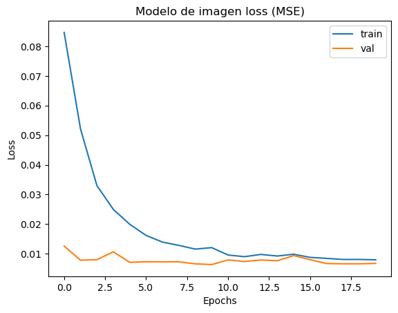

```python
plt.plot(H_tun2.history['loss'], label='train')
plt.plot(H_tun2.history['val_loss'], label='val')
plt.title('Modelo de imagen loss (MSE)')
plt.xlabel('Epochs')
#plt.ylim(0,0.1)
plt.ylabel('Loss')
plt.legend()
plt.show()
```

```python
predictions_image_vgg19_tun2 = model_tun2.predict(images_scaled_test)
```

```python
np.save('predictions_image_vgg19_tun2.npy', predictions_image_vgg19_tun2)
predictions_image_vgg19_tun
```

```
array([[0.05160545],
       [0.11275161],
       [0.03696929],
       ...,
       [0.10414316],
       [0.14072202],
       [0.11453982]], dtype=float32)
```

```python
train_mse_vgg19_tun2 = model_tun2.evaluate(images_scaled_train, y_train_scaled)
val_mse_vgg19_tun2 = model_tun2.evaluate(images_scaled_val, y_val_scaled)
test_mse_vgg19_tun2 = model_tun2.evaluate(images_scaled_test, y_test_scaled)

print("Train Score:", train_mse_vgg19_tun2)
print("Validation Score:", val_mse_vgg19_tun2)
print("Test Score:", test_mse_vgg19_tun2)
```

```
Train Score: [0.00195654621347785, 0.00195654621347785]
Validation Score: [0.006727707106620073, 0.006727707106620073]
Test Score: [0.007736815605312586, 0.007736815605312586]
```

```python
train_rmse_vgg19_tun2 = math.sqrt(train_mse_vgg19_tun2[0])
print('Train Score: %.2f RMSE' % (train_rmse_vgg19_tun2))
val_rmse_vgg19_tun2 = math.sqrt(val_mse_vgg19_tun2[0])
print('Train Score: %.2f RMSE' % (val_rmse_vgg19_tun2))
test_rmse_vgg19_tun2 = math.sqrt(test_mse_vgg19_tun2[0])
print('Test Score: %.2f RMSE' % (test_rmse_vgg19_tun2))

# Ahora lo desescalamos desescalarmos el error no cuadrado para obtener el error en euros:
train_error_vgg19_tun2_euro = scalerY.inverse_transform(np.reshape(train_rmse_vgg19_tun2,(-1,1)))
val_error_vgg19_tun2_euro = scalerY.inverse_transform(np.reshape(val_rmse_vgg19_tun2,(-1,1)))
test_error_vgg19_tun2_euro = scalerY.inverse_transform(np.reshape(test_rmse_vgg19_tun2,(-1,1)))

print('Train error in Euros: %.2f Euros' % (train_error_vgg19_tun2_euro))
print('Train error in Euros: %.2f Euros' % (val_error_vgg19_tun2_euro))
print('Test error in Euros: %.2f Euros' % (test_error_vgg19_tun2_euro))
```

```
Train Score: 0.04 RMSE
Train Score: 0.08 RMSE
Test Score: 0.09 RMSE
Train error in Euros: 47.16 Euros
Train error in Euros: 78.90 Euros
Test error in Euros: 83.89 Euros
```

```python
model_tun2.save("model_tun_pre-last")
```

```
INFO:tensorflow:Assets written to: model_tun_pre-last/assets
```

```
INFO:tensorflow:Assets written to: model_tun_pre-last/assets
```

El modelo no parece mejorar más allá de lo conseguido haciendo fine-tuning del último bloque tras al menos 15 iteraciones en grid search manual. Sin embargo, su progresión parece más estable y lógica así que lo usaremos para la fusión usando Early-Fusion.

## ETAPA 5: MODELADO DE LA RED PARA TABULARES

```python
# Definimos parámetros
do = 0.10

# Crear el modelo
model_tab = Sequential()

# Capa de entrada
n_cols = X_train.shape[1]
model_tab.add(Dense(n_cols, activation='relu', input_shape=(n_cols,)))
model_tab.add(BatchNormalization())
#model_tab.add(Dropout(do))

# Capas ocultas
model_tab.add(Dense(256, activation='relu'))
model_tab.add(BatchNormalization())
#model_tab.add(Dropout(do))

model_tab.add(Dense(512, activation='relu'))
model_tab.add(BatchNormalization())
model_tab.add(Dropout(do))

model_tab.add(Dense(256, activation='relu'))
model_tab.add(BatchNormalization())
#model_tab.add(Dropout(do))

model_tab.add(Dense(n_cols, activation='relu'))
model_tab.add(BatchNormalization())
#model_tab.add(Dropout(do))

# Capa de salida
model_tab.add(Dense(1, activation='linear'))

model_tab.summary()
```

```
Model: "sequential"
_________________________________________________________________
 Layer (type)                Output Shape              Param #
=================================================================
 dense (Dense)               (None, 60)                3660

 batch_normalization (Batch  (None, 60)                240
 Normalization)

 dense_1 (Dense)             (None, 256)               15616

 batch_normalization_1 (Bat  (None, 256)               1024
 chNormalization)

 dense_2 (Dense)             (None, 512)               131584

 batch_normalization_2 (Bat  (None, 512)               2048
 chNormalization)

 dropout (Dropout)           (None, 512)               0

 dense_3 (Dense)             (None, 256)               131328

 batch_normalization_3 (Bat  (None, 256)               1024
 chNormalization)

 dense_4 (Dense)             (None, 60)                15420

 batch_normalization_4 (Bat  (None, 60)                240
 chNormalization)

 dense_5 (Dense)             (None, 1)                 61

=================================================================
Total params: 302245 (1.15 MB)
Trainable params: 299957 (1.14 MB)
Non-trainable params: 2288 (8.94 KB)
_________________________________________________________________
```

```python
# Definimos parámetros de compilación y entrenamiento
batch_size = 128

#batches_train = np.ceil(X_train_norm.shape[0]/batch_size)
#batches_test = np.ceil(X_test_norm.shape[0]/batch_size)
#batches_val = np.ceil(X_al_norm.shape[0]/batch_size)
epochs = 100
lr = 1e-3
decay = 1e-4 / 200

# Compilamos el modelo
model_tab.compile(loss="mean_squared_error", optimizer=Adam(lr), metrics=["mean_squared_error"])

np.random.seed(42)

# Entrenamos el modelo
H_tab = model_tab.fit(X_train_scaled, y_train_scaled, batch_size=batch_size, epochs=epochs, validation_data=(X_val_scaled, y_val_scaled))
```

```
WARNING:absl:At this time, the v2.11+ optimizer `tf.keras.optimizers.Adam` runs slowly on M1/M2 Macs, please use the legacy Keras optimizer instead, located at `tf.keras.optimizers.legacy.Adam`.
```

```
2024-03-10 19:40:23.928208: I tensorflow/core/grappler/optimizers/custom_graph_optimizer_registry.cc:117] Plugin optimizer for device_type GPU is enabled.
2024-03-10 19:40:23.987325: E tensorflow/core/grappler/optimizers/meta_optimizer.cc:961] model_pruner failed: INVALID_ARGUMENT: Graph does not contain terminal node Adam/AssignAddVariableOp.
```

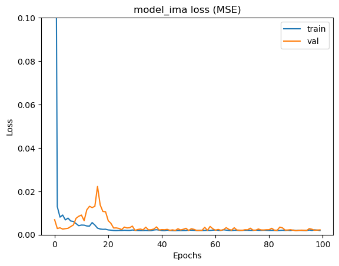

```python
plt.plot(H_tab.history['loss'], label='train')
plt.plot(H_tab.history['val_loss'], label='val')
plt.title('model_ima loss (MSE)')
plt.ylim(0,0.1)
plt.xlabel('Epochs')
plt.ylabel('Loss')
plt.legend()
plt.show()
```

```python
predictions_tab = model_tab.predict(X_test_scaled)
```

```python
np.save('predictions_tab.npy', predictions_tab)
predictions_tab
```

```
array([[-0.00835685],
       [ 0.0283392 ],
       [-0.0030514 ],
       ...,
       [ 0.02513451],
       [ 0.01376101],
       [ 0.12557605]], dtype=float32)
```

```python
train_rmse_tab = math.sqrt(train_tab[0])
print('Train Score: %.2f RMSE' % (train_rmse_tab))
val_rmse_tab = math.sqrt(val_tab[0])
print('Train Score: %.2f RMSE' % (val_rmse_tab))
test_rmse_tab = math.sqrt(test_tab[0])
print('Test Score: %.2f RMSE' % (test_rmse_tab))

# Ahora lo desescalamos desescalarmos el error no cuadrado para obtener el error en euros:
train_error_tab_euro = scalerY.inverse_transform(np.reshape(train_rmse_tab,(-1,1)))
val_error_tab_euro = scalerY.inverse_transform(np.reshape(val_rmse_tab,(-1,1)))
test_error_tab_euro = scalerY.inverse_transform(np.reshape(test_rmse_tab,(-1,1)))

print('Train error in Euros: %.2f Euros' % (train_error_tab_euro))
print('Train error in Euros: %.2f Euros' % (val_error_tab_euro))
print('Test error in Euros: %.2f Euros' % (test_error_tab_euro))
```

```
Train Score: 0.05 RMSE
Train Score: 0.05 RMSE
Test Score: 0.05 RMSE
Train error in Euros: 47.99 Euros
Train error in Euros: 49.77 Euros
Test error in Euros: 52.72 Euros
```

```python
model_tab.save("model_tab")
```

```
INFO:tensorflow:Assets written to: model_tab/assets
```

```
INFO:tensorflow:Assets written to: model_tab/assets
```

El modelo tiene mejores resultados que los mostrados por el CNN.

## ETAPA 6: FUSIÓN DE MODELOS

```python
model_tab = tf.keras.models.load_model('model_tab')
```

```
WARNING:absl:At this time, the v2.11+ optimizer `tf.keras.optimizers.RestoredOptimizer` runs slowly on M1/M2 Macs, please use the legacy Keras optimizer instead, located at `tf.keras.optimizers.legacy.RestoredOptimizer`.
WARNING:absl:At this time, the v2.11+ optimizer `tf.keras.optimizers.Adam` runs slowly on M1/M2 Macs, please use the legacy Keras optimizer instead, located at `tf.keras.optimizers.legacy.Adam`.
```

```python
model_tab.summary()
```

```
Model: "sequential_5"
_________________________________________________________________
 Layer (type)                Output Shape              Param #
=================================================================
 dense_30 (Dense)            (None, 60)                3660

 batch_normalization_25 (Ba  (None, 60)                240
 tchNormalization)

 dense_31 (Dense)            (None, 256)               15616

 batch_normalization_26 (Ba  (None, 256)               1024
 tchNormalization)

 dense_32 (Dense)            (None, 512)               131584

 batch_normalization_27 (Ba  (None, 512)               2048
 tchNormalization)

 dropout_9 (Dropout)         (None, 512)               0

 dense_33 (Dense)            (None, 256)               131328

 batch_normalization_28 (Ba  (None, 256)               1024
 tchNormalization)

 dense_34 (Dense)            (None, 60)                15420

 batch_normalization_29 (Ba  (None, 60)                240
 tchNormalization)

 dense_35 (Dense)            (None, 1)                 61

=================================================================
Total params: 302245 (1.15 MB)
Trainable params: 299957 (1.14 MB)
Non-trainable params: 2288 (8.94 KB)
_________________________________________________________________
```

```python
model_tab.layers[-2]
```

```
<keras.src.layers.normalization.batch_normalization.BatchNormalization at 0x65a5b2590>
```

```python
model_tun2 = tf.keras.models.load_model('model_tun_pre-last')
```

```
WARNING:absl:At this time, the v2.11+ optimizer `tf.keras.optimizers.RestoredOptimizer` runs slowly on M1/M2 Macs, please use the legacy Keras optimizer instead, located at `tf.keras.optimizers.legacy.RestoredOptimizer`.
WARNING:absl:At this time, the v2.11+ optimizer `tf.keras.optimizers.Adam` runs slowly on M1/M2 Macs, please use the legacy Keras optimizer instead, located at `tf.keras.optimizers.legacy.Adam`.
```

```python
model_tun2.summary()
```

```
Model: "model_8"
_________________________________________________________________
 Layer (type)                Output Shape              Param #
=================================================================
 input_1 (InputLayer)        [(None, 224, 224, 3)]     0

 block1_conv1 (Conv2D)       (None, 224, 224, 64)      1792

 block1_conv2 (Conv2D)       (None, 224, 224, 64)      36928

 block1_pool (MaxPooling2D)  (None, 112, 112, 64)      0

 block2_conv1 (Conv2D)       (None, 112, 112, 128)     73856

 block2_conv2 (Conv2D)       (None, 112, 112, 128)     147584

 block2_pool (MaxPooling2D)  (None, 56, 56, 128)       0

 block3_conv1 (Conv2D)       (None, 56, 56, 256)       295168

 block3_conv2 (Conv2D)       (None, 56, 56, 256)       590080

 block3_conv3 (Conv2D)       (None, 56, 56, 256)       590080

 block3_conv4 (Conv2D)       (None, 56, 56, 256)       590080

 block3_pool (MaxPooling2D)  (None, 28, 28, 256)       0

 block4_conv1 (Conv2D)       (None, 28, 28, 512)       1180160

 block4_conv2 (Conv2D)       (None, 28, 28, 512)       2359808

 block4_conv3 (Conv2D)       (None, 28, 28, 512)       2359808

 block4_conv4 (Conv2D)       (None, 28, 28, 512)       2359808

 block4_pool (MaxPooling2D)  (None, 14, 14, 512)       0

 block5_conv1 (Conv2D)       (None, 14, 14, 512)       2359808

 block5_conv2 (Conv2D)       (None, 14, 14, 512)       2359808

 block5_conv3 (Conv2D)       (None, 14, 14, 512)       2359808

 block5_conv4 (Conv2D)       (None, 14, 14, 512)       2359808

 block5_pool (MaxPooling2D)  (None, 7, 7, 512)         0

 flatten_8 (Flatten)         (None, 25088)             0

 fc1 (Dense)                 (None, 5290)              132720810

 dropout_8 (Dropout)         (None, 5290)              0

 predictions (Dense)         (None, 1)                 5291

=================================================================
Total params: 152750485 (582.70 MB)
Trainable params: 135085909 (515.31 MB)
Non-trainable params: 17664576 (67.39 MB)
_________________________________________________________________
```

```python
model_tun2.layers[-4]
```

```
<keras.src.layers.reshaping.flatten.Flatten at 0xc73bb0750>
```

```python
import tensorflow as tf
images_features = Model(inputs=model_tun2.input, outputs=model_tun2.get_layer("flatten_8").output)
tabular_features = Model(inputs=model_tab.input, outputs=model_tab.get_layer("batch_normalization_29").output)
```

```python
tabular_features.summary()
```

```
Model: "model_4"
_________________________________________________________________
 Layer (type)                Output Shape              Param #
=================================================================
 dense_30_input (InputLayer  [(None, 60)]              0
 )

 dense_30 (Dense)            (None, 60)                3660

 batch_normalization_25 (Ba  (None, 60)                240
 tchNormalization)

 dense_31 (Dense)            (None, 256)               15616

 batch_normalization_26 (Ba  (None, 256)               1024
 tchNormalization)

 dense_32 (Dense)            (None, 512)               131584

 batch_normalization_27 (Ba  (None, 512)               2048
 tchNormalization)

 dropout_9 (Dropout)         (None, 512)               0

 dense_33 (Dense)            (None, 256)               131328

 batch_normalization_28 (Ba  (None, 256)               1024
 tchNormalization)

 dense_34 (Dense)            (None, 60)                15420

 batch_normalization_29 (Ba  (None, 60)                240
 tchNormalization)

=================================================================
Total params: 302184 (1.15 MB)
Trainable params: 299896 (1.14 MB)
Non-trainable params: 2288 (8.94 KB)
_________________________________________________________________
```

```python
from keras.layers import concatenate
mixed = concatenate([images_features.output, tabular_features.output])
```

```python
x = Dense(25148, activation="relu")(mixed)
x = Dense(1, activation="linear")(x)

model_fusion = Model(inputs=[model_tun2.input, model_tab.input], outputs=x)

opt = Adam(lr=5e-4)
model_fusion.compile(loss="mean_squared_error", metrics=['mean_squared_error'], optimizer=opt)
```

```
WARNING:absl:At this time, the v2.11+ optimizer `tf.keras.optimizers.Adam` runs slowly on M1/M2 Macs, please use the legacy Keras optimizer instead, located at `tf.keras.optimizers.legacy.Adam`.
WARNING:absl:`lr` is deprecated in Keras optimizer, please use `learning_rate` or use the legacy optimizer, e.g.,tf.keras.optimizers.legacy.Adam.
```

```python
model_fusion.summary()
```

```
Model: "model_5"
__________________________________________________________________________________________________
 Layer (type)                Output Shape                 Param #   Connected to
==================================================================================================
 input_1 (InputLayer)        [(None, 224, 224, 3)]        0         []

 block1_conv1 (Conv2D)       (None, 224, 224, 64)         1792      ['input_1[0][0]']

 block1_conv2 (Conv2D)       (None, 224, 224, 64)         36928     ['block1_conv1[0][0]']

 block1_pool (MaxPooling2D)  (None, 112, 112, 64)         0         ['block1_conv2[0][0]']

 block2_conv1 (Conv2D)       (None, 112, 112, 128)        73856     ['block1_pool[0][0]']

 block2_conv2 (Conv2D)       (None, 112, 112, 128)        147584    ['block2_conv1[0][0]']

 block2_pool (MaxPooling2D)  (None, 56, 56, 128)          0         ['block2_conv2[0][0]']

 block3_conv1 (Conv2D)       (None, 56, 56, 256)          295168    ['block2_pool[0][0]']

 block3_conv2 (Conv2D)       (None, 56, 56, 256)          590080    ['block3_conv1[0][0]']

 block3_conv3 (Conv2D)       (None, 56, 56, 256)          590080    ['block3_conv2[0][0]']

 block3_conv4 (Conv2D)       (None, 56, 56, 256)          590080    ['block3_conv3[0][0]']

 block3_pool (MaxPooling2D)  (None, 28, 28, 256)          0         ['block3_conv4[0][0]']

 dense_30_input (InputLayer  [(None, 60)]                 0         []
 )

 block4_conv1 (Conv2D)       (None, 28, 28, 512)          1180160   ['block3_pool[0][0]']

 dense_30 (Dense)            (None, 60)                   3660      ['dense_30_input[0][0]']

 block4_conv2 (Conv2D)       (None, 28, 28, 512)          2359808   ['block4_conv1[0][0]']

 batch_normalization_25 (Ba  (None, 60)                   240       ['dense_30[0][0]']
 tchNormalization)

```

[output cut: 43 more lines]

```

 concatenate_1 (Concatenate  (None, 25148)                0         ['flatten_8[0][0]',
 )                                                                   'batch_normalization_29[0][0]
                                                                    ']

 dense_8 (Dense)             (None, 25148)                6324470   ['concatenate_1[0][0]']
                                                          52

 dense_9 (Dense)             (None, 1)                    25149     ['dense_8[0][0]']

==================================================================================================
Total params: 652798769 (2.43 GB)
Trainable params: 635131905 (2.37 GB)
Non-trainable params: 17666864 (67.39 MB)
__________________________________________________________________________________________________
```

```python
predict_fusion = model_fusion.predict([images_scaled_test, X_test_scaled])
```

```python
predict_fusion
```

```
array([[ 0.02386279],
       [ 0.05118245],
       [ 0.21961713],
       ...,
       [ 0.0200411 ],
       [-0.04231594],
       [-0.01562402]], dtype=float32)
```

```python
train_fus = model_fusion.evaluate([images_scaled_train, X_train_scaled], y_train_scaled)
val_fus = model_fusion.evaluate([images_scaled_val, X_val_scaled], y_val_scaled)
test_fus = model_fusion.evaluate([images_scaled_test, X_test_scaled], y_test_scaled)

print("Train Score:", train_fus)
print("Validation Score:", val_fus)
print("Test Score:", test_fus)
```

```
Train Score: [0.027884265407919884, 0.027884265407919884]
Validation Score: [0.027096237987279892, 0.027096237987279892]
Test Score: [0.027225885540246964, 0.027225885540246964]
```

```python
train_rmse_fus = math.sqrt(train_fus[0])
print('Train Score: %.2f RMSE' % (train_rmse_fus))
val_rmse_fus = math.sqrt(val_fus[0])
print('Train Score: %.2f RMSE' % (val_rmse_fus))
test_rmse_fus = math.sqrt(test_fus[0])
print('Test Score: %.2f RMSE' % (test_rmse_fus))

# Ahora lo desescalamos desescalarmos el error no cuadrado para obtener el error en euros:
train_error_fus_euro = scalerY.inverse_transform(np.reshape(train_rmse_fus,(-1,1)))
val_error_fus_euro = scalerY.inverse_transform(np.reshape(val_rmse_fus,(-1,1)))
test_error_fus_euro = scalerY.inverse_transform(np.reshape(test_rmse_fus,(-1,1)))

print('Train error in Euros: %.2f Euros' % (train_error_fus_euro))
print('Train error in Euros: %.2f Euros' % (val_error_fus_euro))
print('Test error in Euros: %.2f Euros' % (test_error_fus_euro))
```

```
Train Score: 0.17 RMSE
Train Score: 0.16 RMSE
Test Score: 0.17 RMSE
Train error in Euros: 150.27 Euros
Train error in Euros: 148.27 Euros
Test error in Euros: 148.60 Euros
```

## Conclusión:

A efectos de práctica hemos fusionado dos redes en una sola haciendo Early-Fusion, pero debido a la mala calidad del dataset de imágenes este modelo de arquitectura no es viable para predecir los precios de los alquileres.